# 7) Exploratory Analysis: Original vs. Conversational tweets

We will perform two seperate analyses analogous to the main analysis for the subgroups

- a) Original tweets only
- b) Conversational tweets only

```python
# activate virtual environment "masterenv"
import os
#activate_this = os.path.join("/home/mueller/MA_researcher_wellbeing/masterenv", "bin", "activate_this.py")
#exec(open(activate_this).read(), {'__file__': activate_this})

# import necessary packages
import pandas as pd
import numpy as np
import json
import matplotlib.pyplot as plt
import statsmodels.api as sm
import statsmodels.formula.api as smf
import sys
import warnings
warnings.simplefilter("ignore")
```

# H1

### Prepare dfs for H1

```python
# load df
df_complete = pd.read_json("/home/shared_folder/Twitter_samu/MA_researcher_wellbeing/data/timelines_sentiments_nomiss.json", lines=True)
```

```python
# prepare df for h1 analysis of original tweets only
df_orig_h1 = df_complete[["created_at", "is_reply", "pos_sent", "neg_sent"]]
df_orig_h1 = df_orig_h1[df_orig_h1["is_reply"] == False]
df_orig_h1 = df_orig_h1.drop("is_reply", axis = 1)

print(len(df_orig_h1))
df_orig_h1.head()
```

```
1435212
```

|  | created_at | pos_sent | neg_sent |
| --- | --- | --- | --- |
| 1 | 2021-02-15 10:35:48 | 0.990707 | 0.001824 |
| 2 | 2021-02-15 10:11:53 | 0.451927 | 0.003166 |
| 8 | 2020-11-29 17:32:27 | 0.983503 | 0.004215 |
| 9 | 2020-11-25 16:58:53 | 0.987247 | 0.002779 |
| 13 | 2020-10-28 18:00:00 | 0.977114 | 0.003027 |

```python
# prepare df for h1 analysis of conversational tweets only
df_reply_h1 = df_complete[["created_at", "is_reply", "pos_sent", "neg_sent"]]
df_reply_h1 = df_reply_h1[df_reply_h1["is_reply"] == True]
df_reply_h1 = df_reply_h1.drop("is_reply", axis = 1)

print(len(df_reply_h1))
df_reply_h1.head()
```

```
2053206
```

|  | created_at | pos_sent | neg_sent |
| --- | --- | --- | --- |
| 0 | 2021-02-16 10:36:42 | 0.544962 | 0.007144 |
| 3 | 2021-02-08 17:27:53 | 0.990171 | 0.002222 |
| 4 | 2021-02-02 22:23:36 | 0.913798 | 0.026895 |
| 5 | 2021-01-26 18:49:35 | 0.979797 | 0.004174 |
| 6 | 2020-12-15 20:07:00 | 0.083616 | 0.042315 |

```python
# check whether n min = 100
n_orig = df_orig_h1.resample("W", on="created_at").size()
print(min(n_orig))

n_reply = df_reply_h1.resample("W", on="created_at").size()
print(min(n_reply))
```

```
2145
2720
```

```python
# aggregate weekly
df_orig_h1 = df_orig_h1.resample("W", on="created_at").mean()
df_orig_h1["n"] = n_orig

df_reply_h1 = df_reply_h1.resample("W", on="created_at").mean()
df_reply_h1["n"] = n_reply

# add week variable and dummy coded pandemic variable
data_length = len(df_orig_h1)
weeks = list(range(1, data_length + 1))
df_orig_h1["week_T"] = weeks
df_reply_h1["week_T"] = weeks

pandemic = [0]*52 + [1]*50
df_orig_h1["pandemic_D"] = pandemic
df_reply_h1["pandemic_D"] = pandemic

# show prepared df original
df_orig_h1.head()
```

| created_at | pos_sent | neg_sent | n | week_T | pandemic_D |
| --- | --- | --- | --- | --- | --- |
| 2019-03-17 | 0.483678 | 0.157490 | 10094 | 1 | 0 |
| 2019-03-24 | 0.512566 | 0.133152 | 11042 | 2 | 0 |
| 2019-03-31 | 0.527641 | 0.136968 | 10201 | 3 | 0 |
| 2019-04-07 | 0.520077 | 0.135382 | 11065 | 4 | 0 |
| 2019-04-14 | 0.532836 | 0.130541 | 11076 | 5 | 0 |

```python
# show prepared df conversational
df_reply_h1.head()
```

| created_at | pos_sent | neg_sent | n | week_T | pandemic_D |
| --- | --- | --- | --- | --- | --- |
| 2019-03-17 | 0.470831 | 0.180279 | 9267 | 1 | 0 |
| 2019-03-24 | 0.477431 | 0.181024 | 10555 | 2 | 0 |
| 2019-03-31 | 0.498522 | 0.172415 | 10167 | 3 | 0 |
| 2019-04-07 | 0.493201 | 0.168931 | 10969 | 4 | 0 |
| 2019-04-14 | 0.487651 | 0.175470 | 10799 | 5 | 0 |

## H1: POSITIVE SENTIMENTS

```python
# define dfs
Y = df_orig_h1["pos_sent"]
T = df_orig_h1["week_T"]
D = df_orig_h1["pandemic_D"]
df_o = pd.DataFrame({"Y": Y, "T": T, "D": D})

Y = df_reply_h1["pos_sent"]
T = df_reply_h1["week_T"]
D = df_reply_h1["pandemic_D"]
df_r = pd.DataFrame({"Y": Y, "T": T, "D": D})
```

### original tweets

```python
import pmdarima as pm

# fit the ARIMA model automatically for original df
model = pm.auto_arima(df_o["Y"], seasonal=False, trace=True)
```

```
Performing stepwise search to minimize aic
 ARIMA(2,1,2)(0,0,0)[0] intercept   : AIC=-494.709, Time=0.19 sec
 ARIMA(0,1,0)(0,0,0)[0] intercept   : AIC=-484.151, Time=0.03 sec
 ARIMA(1,1,0)(0,0,0)[0] intercept   : AIC=-485.828, Time=0.02 sec
 ARIMA(0,1,1)(0,0,0)[0] intercept   : AIC=-488.178, Time=0.04 sec
 ARIMA(0,1,0)(0,0,0)[0]             : AIC=-485.874, Time=0.02 sec
 ARIMA(1,1,2)(0,0,0)[0] intercept   : AIC=-497.336, Time=0.14 sec
 ARIMA(0,1,2)(0,0,0)[0] intercept   : AIC=-495.582, Time=0.11 sec
 ARIMA(1,1,1)(0,0,0)[0] intercept   : AIC=inf, Time=0.16 sec
 ARIMA(1,1,3)(0,0,0)[0] intercept   : AIC=-492.537, Time=0.17 sec
 ARIMA(0,1,3)(0,0,0)[0] intercept   : AIC=-494.823, Time=0.12 sec
 ARIMA(2,1,1)(0,0,0)[0] intercept   : AIC=inf, Time=0.13 sec
 ARIMA(2,1,3)(0,0,0)[0] intercept   : AIC=-492.412, Time=0.21 sec
 ARIMA(1,1,2)(0,0,0)[0]             : AIC=-493.293, Time=0.10 sec

Best model:  ARIMA(1,1,2)(0,0,0)[0] intercept
Total fit time: 1.440 seconds
```

```python
from statsmodels.tsa.arima.model import ARIMA

# specify ARIMA model using the proposed parameters
arima_results_o = ARIMA(df_o["Y"], df_o[["T", "D"]], order=(1,1,2)).fit()
print(arima_results_o.summary(alpha=0.025))
```

```
                               SARIMAX Results
==============================================================================
Dep. Variable:                      Y   No. Observations:                  102
Model:                 ARIMA(1, 1, 2)   Log Likelihood                 260.116
Date:                Wed, 23 Oct 2024   AIC                           -508.231
Time:                        06:36:19   BIC                           -492.540
Sample:                    03-17-2019   HQIC                          -501.879
                         - 02-21-2021
Covariance Type:                  opg
==============================================================================
                 coef    std err          z      P>|z|     [0.0125     0.9875]
------------------------------------------------------------------------------
T             -0.0006      0.000     -1.502      0.133      -0.001       0.000
D             -0.0516      0.012     -4.461      0.000      -0.077      -0.026
ar.L1         -0.0524      0.300     -0.175      0.861      -0.724       0.620
ma.L1         -0.4055      0.272     -1.489      0.137      -1.016       0.205
ma.L2         -0.4759      0.250     -1.905      0.057      -1.036       0.084
sigma2         0.0003   4.29e-05      7.787      0.000       0.000       0.000
===================================================================================
Ljung-Box (L1) (Q):                   0.17   Jarque-Bera (JB):               344.93
Prob(Q):                              0.68   Prob(JB):                         0.00
Heteroskedasticity (H):               3.30   Skew:                            -2.08
Prob(H) (two-sided):                  0.00   Kurtosis:                        11.04
===================================================================================

Warnings:
[1] Covariance matrix calculated using the outer product of gradients (complex-step).
```

The descriptive statistic says that the official start of the pandemic had a negative effect on the positive sentiments for orginial tweets. D (dummy coded variable indicating the start of the pandemic) has a coeficient of -0.0516. But some model assumptions are violated (Homoscedasticity (Prob(H)<0.05), normally distributed residuals (Prob(JB)<0.05)). Because of that the inference statistic is not reliable.

Let's use Bootstrapping method to deal our data:

```python
# Define the number of bootstrap samples
n_bootstrap_samples = 1000
coefficient_D_estimates = []

# Set the random seed for reproducibility
np.random.seed(42)

# Define the block size for block bootstrapping
block_size = 3  # how many segments of data are resampled together (I need a quite small block size to capture short-term variation (effect of the start of the pandemic))

# Perform block bootstrapping
for _ in range(n_bootstrap_samples):
    # Generate a bootstrap sample of 'Y' and 'D' using block bootstrapping
    bootstrap_indices = np.random.randint(1, len(df_o) - block_size, len(df_o) // block_size)
    bootstrap_indices = np.repeat(bootstrap_indices, block_size) + np.tile(np.arange(block_size), len(bootstrap_indices))
    bootstrap_sample = df_o.iloc[bootstrap_indices]

    # Fit ARIMA model to the bootstrap sample
    bootstrap_model = ARIMA(bootstrap_sample["Y"], bootstrap_sample[["T", "D"]], order=(1, 1, 2)).fit()

    # Store the estimated coefficient for 'D'
    coefficient_D_estimates.append(bootstrap_model.params["D"])

# Calculate standard errors and confidence intervals for the coefficient of 'D'
coefficient_D_estimates = np.array(coefficient_D_estimates)
coefficient_D_std_error = coefficient_D_estimates.std()
coefficient_D_ci_lower = np.percentile(coefficient_D_estimates, 1.25)
coefficient_D_ci_upper = np.percentile(coefficient_D_estimates, 98.75)

# Print the results
print("Bootstrap Standard Error for Coefficient of 'D':", coefficient_D_std_error)
print("Bootstrap 97.5% Confidence Interval for Coefficient of 'D':")
print("Lower Bound:", coefficient_D_ci_lower)
print("Upper Bound:", coefficient_D_ci_upper)
```

```
Bootstrap Standard Error for Coefficient of 'D': 0.01089259408333309
Bootstrap 97.5% Confidence Interval for Coefficient of 'D':
Lower Bound: -0.07245935987140102
Upper Bound: -0.02383519339846443
```

```
Bootstrap Standard Error for Coefficient of 'D': 0.01089259408333309
Bootstrap 97.5% Confidence Interval for Coefficient of 'D':
Lower Bound: -0.07245935987140102
Upper Bound: -0.02383519339846443
```

Robust estimation of the D coefficient via bootstrapping says that the true value of the D coef lies with 97.5% probability within the range of the **CI [-0.073; -0.024]**. **The ARIMA model suggested a value inside of this interval: -0.0516.** The fact that the ARIMA coefficient falls within the bootstrapped confidence interval indicates that the coefficient estimate is consistent with the resampled data. It provides evidence that the coefficient is statistically valid.

Let's plot this:

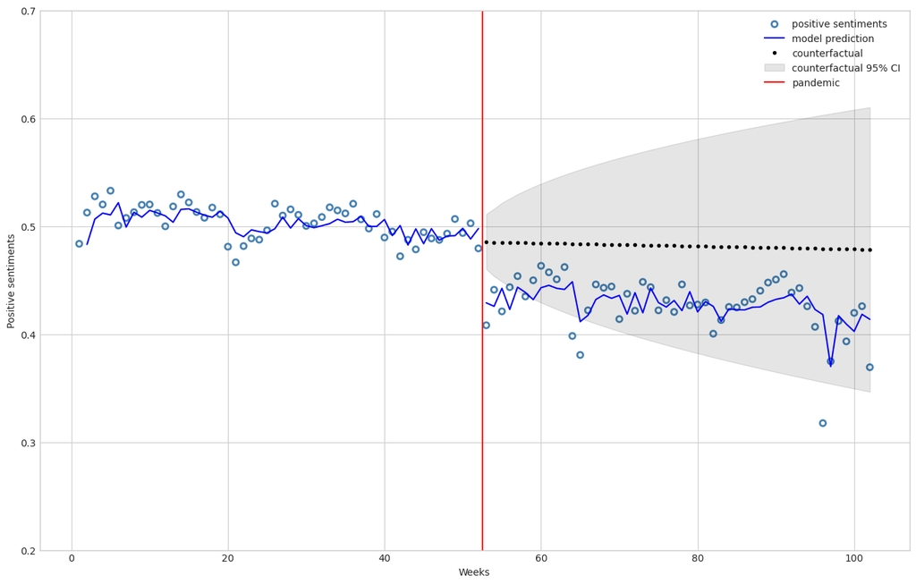

```python
start = 52
end = 102

# get the model predictions for the whole time period (start till end)
predictions = arima_results_o.get_prediction(0, end-1)
summary = predictions.summary_frame(alpha=0.025)

# get the counterfactual ARIMA by fitting a model only for the first time period (before the pandemic)
arima_cf = ARIMA(df_o["Y"][:start], df_o["T"][:start], order=(1,1,2)).fit()

# model predictions means
y_pred = predictions.predicted_mean

# counterfactual mean and 95% confidence interval
y_cf = arima_cf.get_forecast(50, exog=df_o["T"][start:]).summary_frame(alpha=0.05)

# plot section
plt.style.use('seaborn-v0_8-whitegrid')
fig, ax = plt.subplots(figsize=(16,10))

# plot weekly sentiment data
ax.scatter(df_o["T"], df_o["Y"], facecolors='none', edgecolors='steelblue', label="positive sentiments", linewidths=2)

# plot model mean sentiment prediction
ax.plot(df_o["T"][1:start], y_pred[1:start], 'b-', label="model prediction")
ax.plot(df_o["T"][start:], y_pred[start:], 'b-')

# plot counterfactual mean sentiment with 95% confidence interval
ax.plot(df_o["T"][start:], y_cf["mean"], 'k.', label="counterfactual")
ax.fill_between(df_o["T"][start:], y_cf['mean_ci_lower'], y_cf['mean_ci_upper'], color='k', alpha=0.1, label="counterfactual 95% CI")


# plot line marking the week of the official start of the pandemic (WHO)
ax.axvline(x = 52.5, color = 'r', label = 'pandemic')

ax.legend(loc='best')
plt.ylim([0.2, 0.7])
plt.xlabel("Weeks")
plt.ylabel("Positive sentiments")
```

### conversational tweets

```python
# fit the ARIMA model automatically for reply df
model = pm.auto_arima(df_r["Y"], seasonal=False, trace=True)
```

```
Performing stepwise search to minimize aic
 ARIMA(2,1,2)(0,0,0)[0] intercept   : AIC=-555.988, Time=0.25 sec
 ARIMA(0,1,0)(0,0,0)[0] intercept   : AIC=-538.695, Time=0.02 sec
 ARIMA(1,1,0)(0,0,0)[0] intercept   : AIC=-541.377, Time=0.03 sec
 ARIMA(0,1,1)(0,0,0)[0] intercept   : AIC=-546.175, Time=0.06 sec
 ARIMA(0,1,0)(0,0,0)[0]             : AIC=-540.468, Time=0.01 sec
 ARIMA(1,1,2)(0,0,0)[0] intercept   : AIC=inf, Time=0.24 sec
 ARIMA(2,1,1)(0,0,0)[0] intercept   : AIC=-558.532, Time=0.12 sec
 ARIMA(1,1,1)(0,0,0)[0] intercept   : AIC=inf, Time=0.09 sec
 ARIMA(2,1,0)(0,0,0)[0] intercept   : AIC=-542.343, Time=0.03 sec
 ARIMA(3,1,1)(0,0,0)[0] intercept   : AIC=-555.833, Time=0.16 sec
 ARIMA(3,1,0)(0,0,0)[0] intercept   : AIC=-545.143, Time=0.05 sec
 ARIMA(3,1,2)(0,0,0)[0] intercept   : AIC=-555.276, Time=0.10 sec
 ARIMA(2,1,1)(0,0,0)[0]             : AIC=-554.130, Time=0.13 sec

Best model:  ARIMA(2,1,1)(0,0,0)[0] intercept
Total fit time: 1.282 seconds
```

```python
# specify ARIMA model using the proposed parameters
arima_results_r = ARIMA(df_r["Y"], df_r[["T", "D"]], order=(2,1,1)).fit()
print(arima_results_r.summary(alpha=0.025))
```

```
                               SARIMAX Results
==============================================================================
Dep. Variable:                      Y   No. Observations:                  102
Model:                 ARIMA(2, 1, 1)   Log Likelihood                 286.650
Date:                Wed, 23 Oct 2024   AIC                           -561.300
Time:                        06:38:15   BIC                           -545.609
Sample:                    03-17-2019   HQIC                          -554.948
                         - 02-21-2021
Covariance Type:                  opg
==============================================================================
                 coef    std err          z      P>|z|     [0.0125     0.9875]
------------------------------------------------------------------------------
T             -0.0006      0.000     -2.553      0.011      -0.001   -7.05e-05
D             -0.0195      0.008     -2.422      0.015      -0.037      -0.001
ar.L1          0.4515      0.121      3.737      0.000       0.181       0.722
ar.L2         -0.0897      0.151     -0.596      0.551      -0.427       0.248
ma.L1         -0.9508      0.070    -13.583      0.000      -1.108      -0.794
sigma2         0.0002   2.16e-05      9.030      0.000       0.000       0.000
===================================================================================
Ljung-Box (L1) (Q):                   0.02   Jarque-Bera (JB):               138.63
Prob(Q):                              0.89   Prob(JB):                         0.00
Heteroskedasticity (H):               2.62   Skew:                            -1.55
Prob(H) (two-sided):                  0.01   Kurtosis:                         7.83
===================================================================================

Warnings:
[1] Covariance matrix calculated using the outer product of gradients (complex-step).
```

The descriptive statistic says that the official start of the pandemic had a negative effect on the positive sentiments for conversational tweets. D (dummy coded variable indicating the start of the pandemic) has a coeficient of **-0.0195**. But some model assumptions are violated (Homoscedasticity (Prob(H)<0.05), normally distributed residuals (Prob(JB)<0.05)). Because of that the inference statistic is not reliable.

Let's use Bootstrapping method to deal our data:

```python
# Define the number of bootstrap samples
n_bootstrap_samples = 1000
coefficient_D_estimates = []

# Set the random seed for reproducibility
np.random.seed(42)

# Define the block size for block bootstrapping
block_size = 3  # how many segments of data are resampled together (I need a quite small block size to capture short-term variation (effect of the start of the pandemic))

# Perform block bootstrapping
for _ in range(n_bootstrap_samples):
    # Generate a bootstrap sample of 'Y' and 'D' using block bootstrapping
    bootstrap_indices = np.random.randint(1, len(df_r) - block_size, len(df_r) // block_size)
    bootstrap_indices = np.repeat(bootstrap_indices, block_size) + np.tile(np.arange(block_size), len(bootstrap_indices))
    bootstrap_sample = df_r.iloc[bootstrap_indices]

    # Fit ARIMA model to the bootstrap sample
    bootstrap_model = ARIMA(bootstrap_sample["Y"], bootstrap_sample[["T", "D"]], order=(2, 1, 1)).fit()

    # Store the estimated coefficient for 'D'
    coefficient_D_estimates.append(bootstrap_model.params["D"])

# Calculate standard errors and confidence intervals for the coefficient of 'D'
coefficient_D_estimates = np.array(coefficient_D_estimates)
coefficient_D_std_error = coefficient_D_estimates.std()
coefficient_D_ci_lower = np.percentile(coefficient_D_estimates, 1.25)
coefficient_D_ci_upper = np.percentile(coefficient_D_estimates, 98.75)

# Print the results
print("Bootstrap Standard Error for Coefficient of 'D':", coefficient_D_std_error)
print("Bootstrap 97.5% Confidence Interval for Coefficient of 'D':")
print("Lower Bound:", coefficient_D_ci_lower)
print("Upper Bound:", coefficient_D_ci_upper)
```

```
Bootstrap Standard Error for Coefficient of 'D': 0.009456923126919335
Bootstrap 97.5% Confidence Interval for Coefficient of 'D':
Lower Bound: -0.03770567798483115
Upper Bound: 0.0041302056453113335
```

```
Bootstrap Standard Error for Coefficient of 'D': 0.009456923126919335
Bootstrap 97.5% Confidence Interval for Coefficient of 'D':
Lower Bound: -0.03770567798483115
Upper Bound: 0.0041302056453113335
```

CI includes 0! **The ARIMA model suggested a value inside of this interval: -0.0195.**

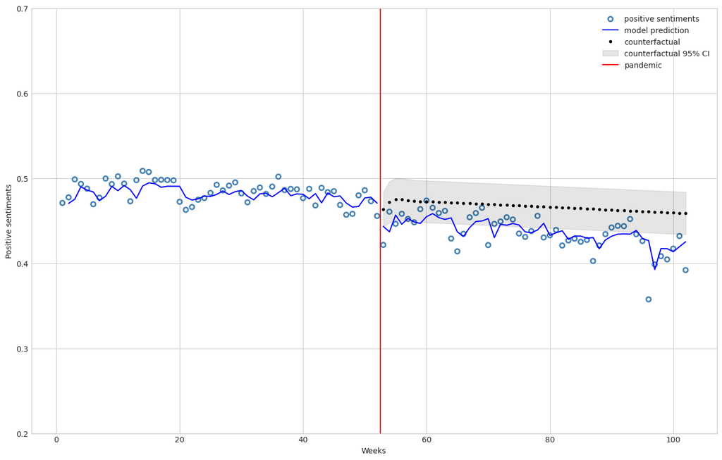

```python
start = 52
end = 102

# get the model predictions for the whole time period (start till end)
predictions = arima_results_r.get_prediction(0, end-1)
summary = predictions.summary_frame(alpha=0.025)

# get the counterfactual ARIMA by fitting a model only for the first time period (before the pandemic)
arima_cf = ARIMA(df_r["Y"][:start], df_r["T"][:start], order=(2,1,1)).fit()

# model predictions means
y_pred = predictions.predicted_mean

# counterfactual mean and 95% confidence interval
y_cf = arima_cf.get_forecast(50, exog=df_r["T"][start:]).summary_frame(alpha=0.05)

# plot section
plt.style.use('seaborn-v0_8-whitegrid')
fig, ax = plt.subplots(figsize=(16,10))

# plot weekly sentiment data
ax.scatter(df_r["T"], df_r["Y"], facecolors='none', edgecolors='steelblue', label="positive sentiments", linewidths=2)

# plot model mean sentiment prediction
ax.plot(df_r["T"][1:start], y_pred[1:start], 'b-', label="model prediction")
ax.plot(df_r["T"][start:], y_pred[start:], 'b-')

# plot counterfactual mean sentiment with 95% confidence interval
ax.plot(df_r["T"][start:], y_cf["mean"], 'k.', label="counterfactual")
ax.fill_between(df_r["T"][start:], y_cf['mean_ci_lower'], y_cf['mean_ci_upper'], color='k', alpha=0.1, label="counterfactual 95% CI")


# plot line marking the week of the official start of the pandemic (WHO)
ax.axvline(x = 52.5, color = 'r', label = 'pandemic')

ax.legend(loc='best')
plt.ylim([0.2, 0.7])
plt.xlabel("Weeks")
plt.ylabel("Positive sentiments")
```

H1: POSITIVE SENTIMENT - original vs. conversational

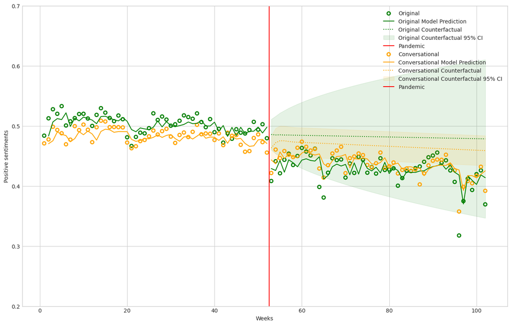

```python
# Define a function to generate the ARIMA plots
def generate_arima_plot(ax, df, arima_order, color, label):
    start = 52
    end = 102

    # Fit ARIMA model
    arima_model = ARIMA(df["Y"], df[["T", "D"]], order=arima_order).fit()

    # Get model predictions for the whole time period (start till end)
    predictions = arima_model.get_prediction(0, end-1)

    # Get the counterfactual ARIMA by fitting a model only for the first time period (before the pandemic)
    arima_cf = ARIMA(df["Y"][:start], df["T"][:start], order=arima_order).fit()

    # Model predictions means
    y_pred = predictions.predicted_mean

    # Counterfactual mean and 95% confidence interval
    y_cf = arima_cf.get_forecast(50, exog=df["T"][start:]).summary_frame(alpha=0.05)

    # Plot weekly sentiment data
    ax.scatter(df["T"], df["Y"], facecolors='none', edgecolors=color, label=label, linewidths=2)

    # Plot model mean sentiment prediction
    ax.plot(df["T"][1:start], y_pred[1:start], color=color, linestyle='-', label=f"{label} Model Prediction")
    ax.plot(df["T"][start:], y_pred[start:], color=color, linestyle='-')

    # Plot counterfactual mean sentiment with 95% confidence interval
    ax.plot(df["T"][start:], y_cf["mean"], color=color, linestyle='dotted', label=f"{label} Counterfactual")
    ax.fill_between(df["T"][start:], y_cf['mean_ci_lower'], y_cf['mean_ci_upper'], color=color, alpha=0.1, label=f"{label} Counterfactual 95% CI")

    # Plot line marking the week of the official start of the pandemic (WHO)
    ax.axvline(x=52.5, color='r', label='Pandemic')

    ax.set_ylim([0.2, 0.7])
    ax.set_xlabel("Weeks")
    ax.set_ylabel("Positive sentiments")
    ax.legend(loc='best')

# Create a single plot
fig, ax = plt.subplots(figsize=(16, 10))

# Specify ARIMA orders for male and female datasets
arima_order_orig = (1, 1, 2)
arima_order_reply = (2, 1, 1)

# Generate the first plot (female data) in green with the specified ARIMA order
generate_arima_plot(ax, df_o, arima_order_orig, color='green', label='Original')

# Generate the second plot (male data) in orange with the specified ARIMA order
generate_arima_plot(ax, df_r, arima_order_reply, color='orange', label='Conversational')

# Show the combined plot
plt.show()
```

## H1: NEGATIVE SENTIMENTS

```python
# define dfs
Y = df_orig_h1["neg_sent"]
T = df_orig_h1["week_T"]
D = df_orig_h1["pandemic_D"]
df_o = pd.DataFrame({"Y": Y, "T": T, "D": D})

Y = df_reply_h1["neg_sent"]
T = df_reply_h1["week_T"]
D = df_reply_h1["pandemic_D"]
df_r = pd.DataFrame({"Y": Y, "T": T, "D": D})
```

### original tweets

```python
# fit the ARIMA model automatically for original df
model = pm.auto_arima(df_o["Y"], seasonal=False, trace=True)
```

```
Performing stepwise search to minimize aic
 ARIMA(2,1,2)(0,0,0)[0] intercept   : AIC=-544.975, Time=0.14 sec
 ARIMA(0,1,0)(0,0,0)[0] intercept   : AIC=-529.765, Time=0.02 sec
 ARIMA(1,1,0)(0,0,0)[0] intercept   : AIC=-532.429, Time=0.04 sec
 ARIMA(0,1,1)(0,0,0)[0] intercept   : AIC=-536.803, Time=0.08 sec
 ARIMA(0,1,0)(0,0,0)[0]             : AIC=-531.417, Time=0.01 sec
 ARIMA(1,1,2)(0,0,0)[0] intercept   : AIC=-547.061, Time=0.08 sec
 ARIMA(0,1,2)(0,0,0)[0] intercept   : AIC=-549.781, Time=0.14 sec
 ARIMA(0,1,3)(0,0,0)[0] intercept   : AIC=-548.135, Time=0.13 sec
 ARIMA(1,1,1)(0,0,0)[0] intercept   : AIC=-550.427, Time=0.13 sec
 ARIMA(2,1,1)(0,0,0)[0] intercept   : AIC=-548.694, Time=0.13 sec
 ARIMA(2,1,0)(0,0,0)[0] intercept   : AIC=-536.178, Time=0.02 sec
 ARIMA(1,1,1)(0,0,0)[0]             : AIC=-543.887, Time=0.09 sec

Best model:  ARIMA(1,1,1)(0,0,0)[0] intercept
Total fit time: 1.023 seconds
```

```python
# specify ARIMA model using the proposed parameters
arima_results_o = ARIMA(df_o["Y"], df_o[["T", "D"]], order=(1,1,1)).fit()
print(arima_results_o.summary(alpha=0.025))
```

```
                               SARIMAX Results
==============================================================================
Dep. Variable:                      Y   No. Observations:                  102
Model:                 ARIMA(1, 1, 1)   Log Likelihood                 282.754
Date:                Wed, 23 Oct 2024   AIC                           -555.508
Time:                        06:40:12   BIC                           -542.432
Sample:                    03-17-2019   HQIC                          -550.214
                         - 02-21-2021
Covariance Type:                  opg
==============================================================================
                 coef    std err          z      P>|z|     [0.0125     0.9875]
------------------------------------------------------------------------------
T              0.0007      0.000      3.104      0.002       0.000       0.001
D              0.0260      0.013      2.018      0.044      -0.003       0.055
ar.L1          0.4531      0.117      3.869      0.000       0.191       0.716
ma.L1         -0.9963      0.350     -2.850      0.004      -1.780      -0.213
sigma2         0.0002   7.35e-05      2.850      0.004    4.48e-05       0.000
===================================================================================
Ljung-Box (L1) (Q):                   0.06   Jarque-Bera (JB):               969.43
Prob(Q):                              0.81   Prob(JB):                         0.00
Heteroskedasticity (H):               4.93   Skew:                             2.91
Prob(H) (two-sided):                  0.00   Kurtosis:                        17.02
===================================================================================

Warnings:
[1] Covariance matrix calculated using the outer product of gradients (complex-step).
```

```python
# Define the number of bootstrap samples
n_bootstrap_samples = 1000
coefficient_D_estimates = []

# Set the random seed for reproducibility
np.random.seed(42)

# Define the block size for block bootstrapping
block_size = 3  # how many segments of data are resampled together (I need a quite small block size to capture short-term variation (effect of the start of the pandemic))

# Perform block bootstrapping
for _ in range(n_bootstrap_samples):
    # Generate a bootstrap sample of 'Y' and 'D' using block bootstrapping
    bootstrap_indices = np.random.randint(1, len(df_o) - block_size, len(df_o) // block_size)
    bootstrap_indices = np.repeat(bootstrap_indices, block_size) + np.tile(np.arange(block_size), len(bootstrap_indices))
    bootstrap_sample = df_o.iloc[bootstrap_indices]

    # Fit ARIMA model to the bootstrap sample
    bootstrap_model = ARIMA(bootstrap_sample["Y"], bootstrap_sample[["T", "D"]], order=(0, 1, 2)).fit()

    # Store the estimated coefficient for 'D'
    coefficient_D_estimates.append(bootstrap_model.params["D"])

# Calculate standard errors and confidence intervals for the coefficient of 'D'
coefficient_D_estimates = np.array(coefficient_D_estimates)
coefficient_D_std_error = coefficient_D_estimates.std()
coefficient_D_ci_lower = np.percentile(coefficient_D_estimates, 1.25)
coefficient_D_ci_upper = np.percentile(coefficient_D_estimates, 98.75)

# Print the results
print("Bootstrap Standard Error for Coefficient of 'D':", coefficient_D_std_error)
print("Bootstrap 97.5% Confidence Interval for Coefficient of 'D':")
print("Lower Bound:", coefficient_D_ci_lower)
print("Upper Bound:", coefficient_D_ci_upper)
```

```
Bootstrap Standard Error for Coefficient of 'D': 0.009121020688311028
Bootstrap 97.5% Confidence Interval for Coefficient of 'D':
Lower Bound: 0.0029223739982179127
Upper Bound: 0.043389094801046066
```

```
Bootstrap Standard Error for Coefficient of 'D': 0.009121020688311028
Bootstrap 97.5% Confidence Interval for Coefficient of 'D':
Lower Bound: 0.0029223739982179127
Upper Bound: 0.043389094801046066
```

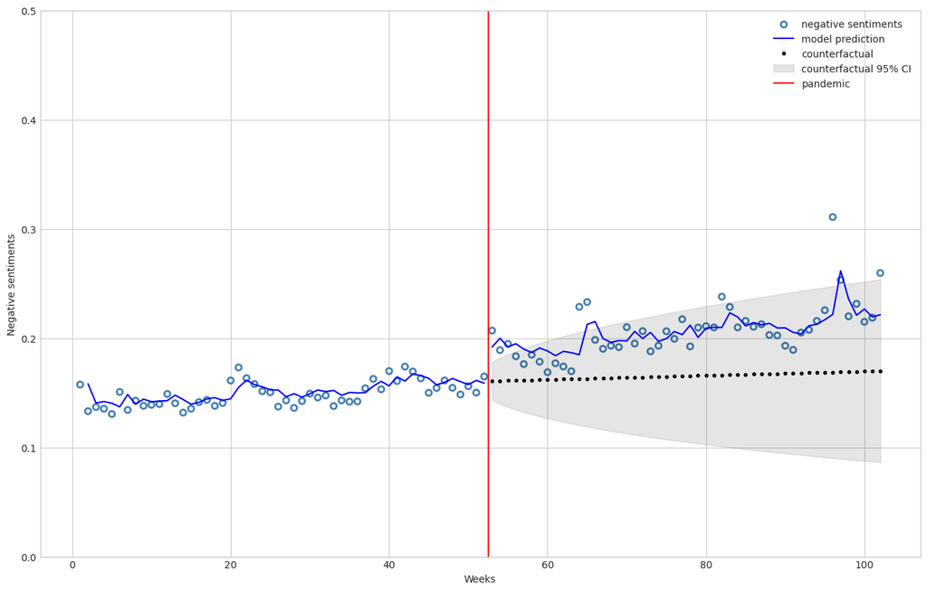

```python
start = 52
end = 102

# get the model predictions for the whole time period (start till end)
predictions = arima_results_o.get_prediction(0, end-1)
summary = predictions.summary_frame(alpha=0.025)

# get the counterfactual ARIMA by fitting a model only for the first time period (before the pandemic)
arima_cf = ARIMA(df_o["Y"][:start], df_o["T"][:start], order=(0,1,2)).fit()

# model predictions means
y_pred = predictions.predicted_mean

# counterfactual mean and 95% confidence interval
y_cf = arima_cf.get_forecast(50, exog=df_o["T"][start:]).summary_frame(alpha=0.05)

# plot section
plt.style.use('seaborn-v0_8-whitegrid')
fig, ax = plt.subplots(figsize=(16,10))

# plot weekly sentiment data
ax.scatter(df_o["T"], df_o["Y"], facecolors='none', edgecolors='steelblue', label="negative sentiments", linewidths=2)

# plot model mean sentiment prediction
ax.plot(df_o["T"][1:start], y_pred[1:start], 'b-', label="model prediction")
ax.plot(df_o["T"][start:], y_pred[start:], 'b-')

# plot counterfactual mean sentiment with 95% confidence interval
ax.plot(df_o["T"][start:], y_cf["mean"], 'k.', label="counterfactual")
ax.fill_between(df_o["T"][start:], y_cf['mean_ci_lower'], y_cf['mean_ci_upper'], color='k', alpha=0.1, label="counterfactual 95% CI")


# plot line marking the week of the official start of the pandemic (WHO)
ax.axvline(x = 52.5, color = 'r', label = 'pandemic')

ax.legend(loc='best')
plt.ylim([0, 0.5])
plt.xlabel("Weeks")
plt.ylabel("Negative sentiments")
```

### conversational tweets

```python
# fit the ARIMA model automatically for reply df
model = pm.auto_arima(df_r["Y"], seasonal=False, trace=True)
```

```
Performing stepwise search to minimize aic
 ARIMA(2,1,2)(0,0,0)[0] intercept   : AIC=-596.159, Time=0.16 sec
 ARIMA(0,1,0)(0,0,0)[0] intercept   : AIC=-601.071, Time=0.02 sec
 ARIMA(1,1,0)(0,0,0)[0] intercept   : AIC=-602.478, Time=0.04 sec
 ARIMA(0,1,1)(0,0,0)[0] intercept   : AIC=-605.252, Time=0.05 sec
 ARIMA(0,1,0)(0,0,0)[0]             : AIC=-602.633, Time=0.01 sec
 ARIMA(1,1,1)(0,0,0)[0] intercept   : AIC=-620.338, Time=0.09 sec
 ARIMA(2,1,1)(0,0,0)[0] intercept   : AIC=-619.485, Time=0.26 sec
 ARIMA(1,1,2)(0,0,0)[0] intercept   : AIC=-615.302, Time=0.13 sec
 ARIMA(0,1,2)(0,0,0)[0] intercept   : AIC=-614.871, Time=0.08 sec
 ARIMA(2,1,0)(0,0,0)[0] intercept   : AIC=-603.018, Time=0.04 sec
 ARIMA(1,1,1)(0,0,0)[0]             : AIC=-614.708, Time=0.05 sec

Best model:  ARIMA(1,1,1)(0,0,0)[0] intercept
Total fit time: 0.943 seconds
```

```python
# specify ARIMA model using the proposed parameters
arima_results_r = ARIMA(df_r["Y"], df_r[["T", "D"]], order=(1,1,1)).fit()
print(arima_results_r.summary(alpha=0.025))
```

```
                               SARIMAX Results
==============================================================================
Dep. Variable:                      Y   No. Observations:                  102
Model:                 ARIMA(1, 1, 1)   Log Likelihood                 314.795
Date:                Wed, 23 Oct 2024   AIC                           -619.590
Time:                        06:41:45   BIC                           -606.514
Sample:                    03-17-2019   HQIC                          -614.296
                         - 02-21-2021
Covariance Type:                  opg
==============================================================================
                 coef    std err          z      P>|z|     [0.0125     0.9875]
------------------------------------------------------------------------------
T              0.0006      0.000      3.039      0.002       0.000       0.001
D              0.0083      0.010      0.831      0.406      -0.014       0.031
ar.L1          0.4789      0.116      4.142      0.000       0.220       0.738
ma.L1         -0.9645      0.061    -15.691      0.000      -1.102      -0.827
sigma2         0.0001    1.2e-05      9.372      0.000    8.59e-05       0.000
===================================================================================
Ljung-Box (L1) (Q):                   0.12   Jarque-Bera (JB):               357.87
Prob(Q):                              0.73   Prob(JB):                         0.00
Heteroskedasticity (H):               3.10   Skew:                             2.21
Prob(H) (two-sided):                  0.00   Kurtosis:                        11.10
===================================================================================

Warnings:
[1] Covariance matrix calculated using the outer product of gradients (complex-step).
```

```python
# Define the number of bootstrap samples
n_bootstrap_samples = 1000
coefficient_D_estimates = []

# Set the random seed for reproducibility
np.random.seed(42)

# Define the block size for block bootstrapping
block_size = 3  # how many segments of data are resampled together (I need a quite small block size to capture short-term variation (effect of the start of the pandemic))

# Perform block bootstrapping
for _ in range(n_bootstrap_samples):
    # Generate a bootstrap sample of 'Y' and 'D' using block bootstrapping
    bootstrap_indices = np.random.randint(1, len(df_r) - block_size, len(df_r) // block_size)
    bootstrap_indices = np.repeat(bootstrap_indices, block_size) + np.tile(np.arange(block_size), len(bootstrap_indices))
    bootstrap_sample = df_r.iloc[bootstrap_indices]

    # Fit ARIMA model to the bootstrap sample
    bootstrap_model = ARIMA(bootstrap_sample["Y"], bootstrap_sample[["T", "D"]], order=(1, 1, 1)).fit()

    # Store the estimated coefficient for 'D'
    coefficient_D_estimates.append(bootstrap_model.params["D"])

# Calculate standard errors and confidence intervals for the coefficient of 'D'
coefficient_D_estimates = np.array(coefficient_D_estimates)
coefficient_D_std_error = coefficient_D_estimates.std()
coefficient_D_ci_lower = np.percentile(coefficient_D_estimates, 1.25)
coefficient_D_ci_upper = np.percentile(coefficient_D_estimates, 98.75)

# Print the results
print("Bootstrap Standard Error for Coefficient of 'D':", coefficient_D_std_error)
print("Bootstrap 97.5% Confidence Interval for Coefficient of 'D':")
print("Lower Bound:", coefficient_D_ci_lower)
print("Upper Bound:", coefficient_D_ci_upper)
```

```
Bootstrap Standard Error for Coefficient of 'D': 0.007294627649836278
Bootstrap 97.5% Confidence Interval for Coefficient of 'D':
Lower Bound: -0.00865370072134773
Upper Bound: 0.02482254669146327
```

```
Bootstrap Standard Error for Coefficient of 'D': 0.007294627649836278
Bootstrap 97.5% Confidence Interval for Coefficient of 'D':
Lower Bound: -0.00865370072134773
Upper Bound: 0.02482254669146327
```

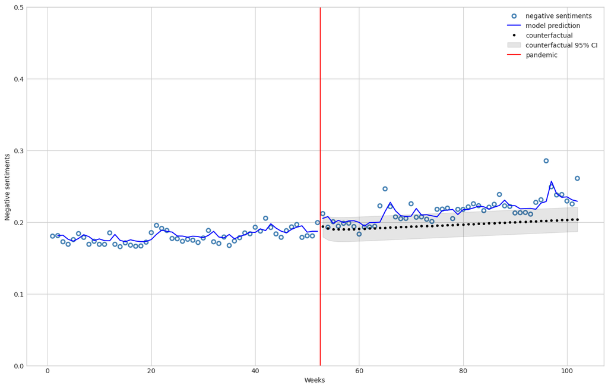

```python
start = 52
end = 102

# get the model predictions for the whole time period (start till end)
predictions = arima_results_r.get_prediction(0, end-1)
summary = predictions.summary_frame(alpha=0.025)

# get the counterfactual ARIMA by fitting a model only for the first time period (before the pandemic)
arima_cf = ARIMA(df_r["Y"][:start], df_r["T"][:start], order=(1,1,1)).fit()

# model predictions means
y_pred = predictions.predicted_mean

# counterfactual mean and 95% confidence interval
y_cf = arima_cf.get_forecast(50, exog=df_r["T"][start:]).summary_frame(alpha=0.05)

# plot section
plt.style.use('seaborn-v0_8-whitegrid')
fig, ax = plt.subplots(figsize=(16,10))

# plot weekly sentiment data
ax.scatter(df_r["T"], df_r["Y"], facecolors='none', edgecolors='steelblue', label="negative sentiments", linewidths=2)

# plot model mean sentiment prediction
ax.plot(df_r["T"][1:start], y_pred[1:start], 'b-', label="model prediction")
ax.plot(df_r["T"][start:], y_pred[start:], 'b-')

# plot counterfactual mean sentiment with 95% confidence interval
ax.plot(df_r["T"][start:], y_cf["mean"], 'k.', label="counterfactual")
ax.fill_between(df_r["T"][start:], y_cf['mean_ci_lower'], y_cf['mean_ci_upper'], color='k', alpha=0.1, label="counterfactual 95% CI")


# plot line marking the week of the official start of the pandemic (WHO)
ax.axvline(x = 52.5, color = 'r', label = 'pandemic')

ax.legend(loc='best')
plt.ylim([0, 0.5])
plt.xlabel("Weeks")
plt.ylabel("Negative sentiments")
```

H1: NEGATIVE SENTIMENT - original vs. conversational

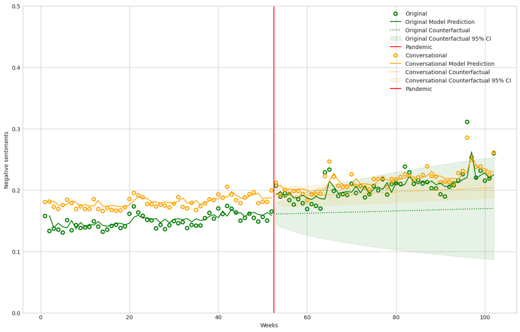

```python
# Define a function to generate the ARIMA plots
def generate_arima_plot(ax, df, arima_order, color, label):
    start = 52
    end = 102

    # Fit ARIMA model
    arima_model = ARIMA(df["Y"], df[["T", "D"]], order=arima_order).fit()

    # Get model predictions for the whole time period (start till end)
    predictions = arima_model.get_prediction(0, end-1)

    # Get the counterfactual ARIMA by fitting a model only for the first time period (before the pandemic)
    arima_cf = ARIMA(df["Y"][:start], df["T"][:start], order=arima_order).fit()

    # Model predictions means
    y_pred = predictions.predicted_mean

    # Counterfactual mean and 95% confidence interval
    y_cf = arima_cf.get_forecast(50, exog=df["T"][start:]).summary_frame(alpha=0.05)

    # Plot weekly sentiment data
    ax.scatter(df["T"], df["Y"], facecolors='none', edgecolors=color, label=label, linewidths=2)

    # Plot model mean sentiment prediction
    ax.plot(df["T"][1:start], y_pred[1:start], color=color, linestyle='-', label=f"{label} Model Prediction")
    ax.plot(df["T"][start:], y_pred[start:], color=color, linestyle='-')

    # Plot counterfactual mean sentiment with 95% confidence interval
    ax.plot(df["T"][start:], y_cf["mean"], color=color, linestyle='dotted', label=f"{label} Counterfactual")
    ax.fill_between(df["T"][start:], y_cf['mean_ci_lower'], y_cf['mean_ci_upper'], color=color, alpha=0.1, label=f"{label} Counterfactual 95% CI")

    # Plot line marking the week of the official start of the pandemic (WHO)
    ax.axvline(x=52.5, color='r', label='Pandemic')

    ax.set_ylim([0, 0.5])
    ax.set_xlabel("Weeks")
    ax.set_ylabel("Negative sentiments")
    ax.legend(loc='best')

# Create a single plot
fig, ax = plt.subplots(figsize=(16, 10))

# Specify ARIMA orders for male and female datasets
arima_order_orig = (0, 1, 2)
arima_order_reply = (1, 1, 1)

# Generate the first plot (female data) in green with the specified ARIMA order
generate_arima_plot(ax, df_o, arima_order_orig, color='green', label='Original')

# Generate the second plot (male data) in orange with the specified ARIMA order
generate_arima_plot(ax, df_r, arima_order_reply, color='orange', label='Conversational')

# Show the combined plot
plt.show()
```

# H2

### prepare df for H2: original tweets

```python
# prepare df for h2 analysis of original tweets only
df_orig_h2 = df_complete[["created_at", "is_reply", "pos_sent", "neg_sent", "gender"]]
df_orig_h2 = df_orig_h2[df_orig_h2["is_reply"] == False]
df_orig_h2 = df_orig_h2.drop("is_reply", axis = 1)

# female df
df_orig_h2_f = df_orig_h2[df_orig_h2["gender"] == "female"]
df_orig_h2_f = df_orig_h2_f.drop("gender", axis = 1)

# male df
df_orig_h2_m = df_orig_h2[df_orig_h2["gender"] == "male"]
df_orig_h2_m = df_orig_h2_m.drop("gender", axis = 1)

print(len(df_orig_h2_f))
df_orig_h2_f.head()
```

```
565953
```

|  | created_at | pos_sent | neg_sent |
| --- | --- | --- | --- |
| 1 | 2021-02-15 10:35:48 | 0.990707 | 0.001824 |
| 2 | 2021-02-15 10:11:53 | 0.451927 | 0.003166 |
| 8 | 2020-11-29 17:32:27 | 0.983503 | 0.004215 |
| 9 | 2020-11-25 16:58:53 | 0.987247 | 0.002779 |
| 13 | 2020-10-28 18:00:00 | 0.977114 | 0.003027 |

```python
print(len(df_orig_h2_m))
df_orig_h2_m.head()
```

```
503058
```

|  | created_at | pos_sent | neg_sent |
| --- | --- | --- | --- |
| 96 | 2020-07-26 10:11:45 | 0.983283 | 0.003322 |
| 97 | 2019-11-16 13:35:45 | 0.373348 | 0.005409 |
| 98 | 2019-10-31 09:42:24 | 0.811625 | 0.005845 |
| 99 | 2019-10-28 12:53:38 | 0.961541 | 0.003030 |
| 100 | 2019-03-21 09:06:17 | 0.470365 | 0.004645 |

```python
# check whether n min = 100
n_orig_f = df_orig_h2_f.resample("W", on="created_at").size()
print(min(n_orig_f))

n_orig_m = df_orig_h2_m.resample("W", on="created_at").size()
print(min(n_orig_m))
```

```
550
616
```

```python
# aggregate weekly
df_orig_h2_f = df_orig_h2_f.resample("W", on="created_at").mean()
df_orig_h2_f["n"] = n_orig_f

df_orig_h2_m = df_orig_h2_m.resample("W", on="created_at").mean()
df_orig_h2_m["n"] = n_orig_m

# add week variable and dummy coded pandemic variable
df_orig_h2_f["week_T"] = weeks
df_orig_h2_m["week_T"] = weeks

df_orig_h2_f["pandemic_D"] = pandemic
df_orig_h2_m["pandemic_D"] = pandemic

# show prepared df female
df_orig_h2_f.head()
```

| created_at | pos_sent | neg_sent | n | week_T | pandemic_D |
| --- | --- | --- | --- | --- | --- |
| 2019-03-17 | 0.539711 | 0.143404 | 4216 | 1 | 0 |
| 2019-03-24 | 0.569247 | 0.114805 | 4824 | 2 | 0 |
| 2019-03-31 | 0.584428 | 0.124302 | 4354 | 3 | 0 |
| 2019-04-07 | 0.575907 | 0.115759 | 4773 | 4 | 0 |
| 2019-04-14 | 0.605815 | 0.108675 | 4641 | 5 | 0 |

### prepare df for H2: conversational tweets

```python
# prepare df for h2 analysis of conv tweets only
df_reply_h2 = df_complete[["created_at", "is_reply", "pos_sent", "neg_sent", "gender"]]
df_reply_h2 = df_reply_h2[df_reply_h2["is_reply"] == True]
df_reply_h2 = df_reply_h2.drop("is_reply", axis = 1)

# female df
df_reply_h2_f = df_reply_h2[df_reply_h2["gender"] == "female"]
df_reply_h2_f = df_reply_h2_f.drop("gender", axis = 1)

# male df
df_reply_h2_m = df_reply_h2[df_reply_h2["gender"] == "male"]
df_reply_h2_m = df_reply_h2_m.drop("gender", axis = 1)

print(len(df_reply_h2_f))
df_reply_h2_f.head()
```

```
810082
```

|  | created_at | pos_sent | neg_sent |
| --- | --- | --- | --- |
| 0 | 2021-02-16 10:36:42 | 0.544962 | 0.007144 |
| 3 | 2021-02-08 17:27:53 | 0.990171 | 0.002222 |
| 4 | 2021-02-02 22:23:36 | 0.913798 | 0.026895 |
| 5 | 2021-01-26 18:49:35 | 0.979797 | 0.004174 |
| 6 | 2020-12-15 20:07:00 | 0.083616 | 0.042315 |

```python
print(len(df_reply_h2_m))
df_reply_h2_m.head()
```

```
729657
```

|  | created_at | pos_sent | neg_sent |
| --- | --- | --- | --- |
| 112 | 2021-02-18 16:07:24 | 0.077275 | 0.068641 |
| 113 | 2021-02-16 10:04:53 | 0.024560 | 0.194774 |
| 114 | 2021-02-05 22:50:49 | 0.017878 | 0.626792 |
| 115 | 2021-01-27 13:45:24 | 0.380987 | 0.086040 |
| 116 | 2021-01-25 16:03:33 | 0.147936 | 0.129056 |

```python
# check whether n min = 100
n_reply_f = df_reply_h2_f.resample("W", on="created_at").size()
print(min(n_reply_f))

n_reply_m = df_reply_h2_m.resample("W", on="created_at").size()
print(min(n_reply_m))
```

```
826
671
```

```python
# aggregate weekly
df_reply_h2_f = df_reply_h2_f.resample("W", on="created_at").mean()
df_reply_h2_f["n"] = n_reply_f

df_reply_h2_m = df_reply_h2_m.resample("W", on="created_at").mean()
df_reply_h2_m["n"] = n_reply_m

# add week variable and dummy coded pandemic variable
df_reply_h2_f["week_T"] = weeks
df_reply_h2_m["week_T"] = weeks

df_reply_h2_f["pandemic_D"] = pandemic
df_reply_h2_m["pandemic_D"] = pandemic

# show prepared df female
df_reply_h2_f.head()
```

| created_at | pos_sent | neg_sent | n | week_T | pandemic_D |
| --- | --- | --- | --- | --- | --- |
| 2019-03-17 | 0.550250 | 0.152465 | 3670 | 1 | 0 |
| 2019-03-24 | 0.536511 | 0.158095 | 4624 | 2 | 0 |
| 2019-03-31 | 0.555151 | 0.151883 | 4383 | 3 | 0 |
| 2019-04-07 | 0.570822 | 0.141928 | 4746 | 4 | 0 |
| 2019-04-14 | 0.571777 | 0.143052 | 4352 | 5 | 0 |

## H2: POSITIVE SENTIMENTS - original tweets

```python
# define dfs
Y = df_orig_h2_f["pos_sent"]
T = df_orig_h2_f["week_T"]
D = df_orig_h2_f["pandemic_D"]
df_of = pd.DataFrame({"Y": Y, "T": T, "D": D})

Y = df_orig_h2_m["pos_sent"]
T = df_orig_h2_m["week_T"]
D = df_orig_h2_m["pandemic_D"]
df_om = pd.DataFrame({"Y": Y, "T": T, "D": D})
```

### pos, original tweets - female

```python
# fit the ARIMA model automatically for original df
model = pm.auto_arima(df_of["Y"], seasonal=False, trace=True)
```

```
Performing stepwise search to minimize aic
 ARIMA(2,1,2)(0,0,0)[0] intercept   : AIC=-473.039, Time=0.25 sec
 ARIMA(0,1,0)(0,0,0)[0] intercept   : AIC=-461.519, Time=0.02 sec
 ARIMA(1,1,0)(0,0,0)[0] intercept   : AIC=-462.729, Time=0.03 sec
 ARIMA(0,1,1)(0,0,0)[0] intercept   : AIC=-464.724, Time=0.04 sec
 ARIMA(0,1,0)(0,0,0)[0]             : AIC=-463.387, Time=0.02 sec
 ARIMA(1,1,2)(0,0,0)[0] intercept   : AIC=-471.365, Time=0.12 sec
 ARIMA(2,1,1)(0,0,0)[0] intercept   : AIC=-474.679, Time=0.13 sec
 ARIMA(1,1,1)(0,0,0)[0] intercept   : AIC=inf, Time=0.11 sec
 ARIMA(2,1,0)(0,0,0)[0] intercept   : AIC=-464.196, Time=0.04 sec
 ARIMA(3,1,1)(0,0,0)[0] intercept   : AIC=-472.414, Time=0.16 sec
 ARIMA(3,1,0)(0,0,0)[0] intercept   : AIC=-462.672, Time=0.06 sec
 ARIMA(3,1,2)(0,0,0)[0] intercept   : AIC=-470.568, Time=0.14 sec
 ARIMA(2,1,1)(0,0,0)[0]             : AIC=-471.311, Time=0.08 sec

Best model:  ARIMA(2,1,1)(0,0,0)[0] intercept
Total fit time: 1.203 seconds
```

```python
# specify ARIMA model using the proposed parameters
arima_results_of = ARIMA(df_of["Y"], df_of[["T", "D"]], order=(2,1,1)).fit()
print(arima_results_of.summary(alpha=0.025))
```

```
                               SARIMAX Results
==============================================================================
Dep. Variable:                      Y   No. Observations:                  102
Model:                 ARIMA(2, 1, 1)   Log Likelihood                 250.611
Date:                Wed, 23 Oct 2024   AIC                           -489.222
Time:                        06:43:25   BIC                           -473.531
Sample:                    03-17-2019   HQIC                          -482.870
                         - 02-21-2021
Covariance Type:                  opg
==============================================================================
                 coef    std err          z      P>|z|     [0.0125     0.9875]
------------------------------------------------------------------------------
T             -0.0004      0.000     -1.073      0.283      -0.001       0.000
D             -0.0607      0.013     -4.707      0.000      -0.090      -0.032
ar.L1          0.5504      0.112      4.915      0.000       0.299       0.801
ar.L2         -0.0647      0.141     -0.460      0.646      -0.380       0.251
ma.L1         -0.9658      0.092    -10.504      0.000      -1.172      -0.760
sigma2         0.0004   5.35e-05      7.401      0.000       0.000       0.001
===================================================================================
Ljung-Box (L1) (Q):                   0.01   Jarque-Bera (JB):               179.78
Prob(Q):                              0.91   Prob(JB):                         0.00
Heteroskedasticity (H):               2.75   Skew:                            -1.65
Prob(H) (two-sided):                  0.00   Kurtosis:                         8.64
===================================================================================

Warnings:
[1] Covariance matrix calculated using the outer product of gradients (complex-step).
```

```python
# Define the number of bootstrap samples
n_bootstrap_samples = 1000
coefficient_D_estimates = []

# Set the random seed for reproducibility
np.random.seed(42)

# Define the block size for block bootstrapping
block_size = 3  # how many segments of data are resampled together (I need a quite small block size to capture short-term variation (effect of the start of the pandemic))

# Perform block bootstrapping
for _ in range(n_bootstrap_samples):
    # Generate a bootstrap sample of 'Y' and 'D' using block bootstrapping
    bootstrap_indices = np.random.randint(1, len(df_of) - block_size, len(df_of) // block_size)
    bootstrap_indices = np.repeat(bootstrap_indices, block_size) + np.tile(np.arange(block_size), len(bootstrap_indices))
    bootstrap_sample = df_of.iloc[bootstrap_indices]

    # Fit ARIMA model to the bootstrap sample
    bootstrap_model = ARIMA(bootstrap_sample["Y"], bootstrap_sample[["T", "D"]], order=(2, 1, 2)).fit()

    # Store the estimated coefficient for 'D'
    coefficient_D_estimates.append(bootstrap_model.params["D"])

# Calculate standard errors and confidence intervals for the coefficient of 'D'
coefficient_D_estimates = np.array(coefficient_D_estimates)
coefficient_D_std_error = coefficient_D_estimates.std()
coefficient_D_ci_lower = np.percentile(coefficient_D_estimates, 1.25)
coefficient_D_ci_upper = np.percentile(coefficient_D_estimates, 98.75)

# Print the results
print("Bootstrap Standard Error for Coefficient of 'D':", coefficient_D_std_error)
print("Bootstrap 97.5% Confidence Interval for Coefficient of 'D':")
print("Lower Bound:", coefficient_D_ci_lower)
print("Upper Bound:", coefficient_D_ci_upper)
```

```
Bootstrap Standard Error for Coefficient of 'D': 0.013644026385285828
Bootstrap 97.5% Confidence Interval for Coefficient of 'D':
Lower Bound: -0.08100321952655572
Upper Bound: -0.020270709757656238
```

```
Bootstrap Standard Error for Coefficient of 'D': 0.013644026385285828
Bootstrap 97.5% Confidence Interval for Coefficient of 'D':
Lower Bound: -0.08100321952655572
Upper Bound: -0.02027070975765623
```

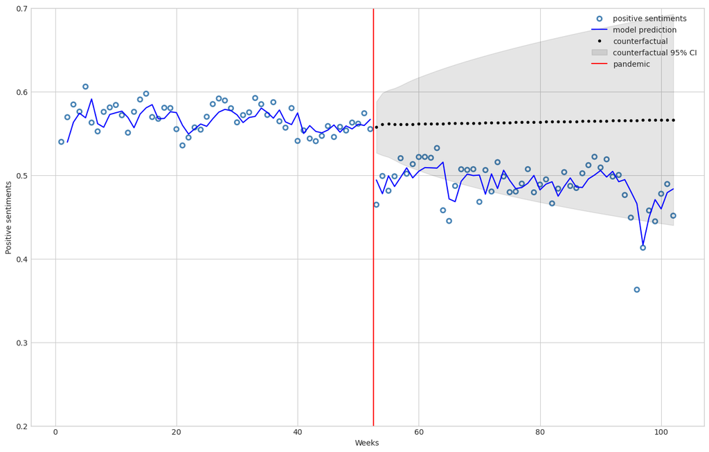

```python
start = 52
end = 102

# get the model predictions for the whole time period (start till end)
predictions = arima_results_of.get_prediction(0, end-1)
summary = predictions.summary_frame(alpha=0.025)

# get the counterfactual ARIMA by fitting a model only for the first time period (before the pandemic)
arima_cf = ARIMA(df_of["Y"][:start], df_of["T"][:start], order=(2,1,2)).fit()

# model predictions means
y_pred = predictions.predicted_mean

# counterfactual mean and 95% confidence interval
y_cf = arima_cf.get_forecast(50, exog=df_of["T"][start:]).summary_frame(alpha=0.05)

# plot section
plt.style.use('seaborn-v0_8-whitegrid')
fig, ax = plt.subplots(figsize=(16,10))

# plot weekly sentiment data
ax.scatter(df_of["T"], df_of["Y"], facecolors='none', edgecolors='steelblue', label="positive sentiments", linewidths=2)

# plot model mean sentiment prediction
ax.plot(df_of["T"][1:start], y_pred[1:start], 'b-', label="model prediction")
ax.plot(df_of["T"][start:], y_pred[start:], 'b-')

# plot counterfactual mean sentiment with 95% confidence interval
ax.plot(df_of["T"][start:], y_cf["mean"], 'k.', label="counterfactual")
ax.fill_between(df_of["T"][start:], y_cf['mean_ci_lower'], y_cf['mean_ci_upper'], color='k', alpha=0.1, label="counterfactual 95% CI")


# plot line marking the week of the official start of the pandemic (WHO)
ax.axvline(x = 52.5, color = 'r', label = 'pandemic')

ax.legend(loc='best')
plt.ylim([0.2, 0.7])
plt.xlabel("Weeks")
plt.ylabel("Positive sentiments")
```

### pos, original tweets - male

```python
# fit the ARIMA model automatically for original df
model = pm.auto_arima(df_om["Y"], seasonal=False, trace=True)
```

```
Performing stepwise search to minimize aic
 ARIMA(2,1,2)(0,0,0)[0] intercept   : AIC=inf, Time=0.11 sec
 ARIMA(0,1,0)(0,0,0)[0] intercept   : AIC=-490.061, Time=0.02 sec
 ARIMA(1,1,0)(0,0,0)[0] intercept   : AIC=-494.338, Time=0.05 sec
 ARIMA(0,1,1)(0,0,0)[0] intercept   : AIC=-498.144, Time=0.11 sec
 ARIMA(0,1,0)(0,0,0)[0]             : AIC=-491.922, Time=0.02 sec
 ARIMA(1,1,1)(0,0,0)[0] intercept   : AIC=inf, Time=0.10 sec
 ARIMA(0,1,2)(0,0,0)[0] intercept   : AIC=-504.097, Time=0.08 sec
 ARIMA(1,1,2)(0,0,0)[0] intercept   : AIC=-506.504, Time=0.15 sec
 ARIMA(1,1,3)(0,0,0)[0] intercept   : AIC=-503.304, Time=0.20 sec
 ARIMA(0,1,3)(0,0,0)[0] intercept   : AIC=-504.883, Time=0.24 sec
 ARIMA(2,1,1)(0,0,0)[0] intercept   : AIC=-507.476, Time=0.15 sec
 ARIMA(2,1,0)(0,0,0)[0] intercept   : AIC=-495.285, Time=0.05 sec
 ARIMA(3,1,1)(0,0,0)[0] intercept   : AIC=-503.825, Time=0.15 sec
 ARIMA(3,1,0)(0,0,0)[0] intercept   : AIC=-494.471, Time=0.04 sec
 ARIMA(3,1,2)(0,0,0)[0] intercept   : AIC=inf, Time=0.20 sec
 ARIMA(2,1,1)(0,0,0)[0]             : AIC=-503.019, Time=0.08 sec

Best model:  ARIMA(2,1,1)(0,0,0)[0] intercept
Total fit time: 1.744 seconds
```

```python
# specify ARIMA model using the proposed parameters
arima_results_om = ARIMA(df_om["Y"], df_om[["T", "D"]], order=(2,1,1)).fit()
print(arima_results_om.summary(alpha=0.025))
```

```
                               SARIMAX Results
==============================================================================
Dep. Variable:                      Y   No. Observations:                  102
Model:                 ARIMA(2, 1, 1)   Log Likelihood                 265.814
Date:                Wed, 23 Oct 2024   AIC                           -519.627
Time:                        06:45:51   BIC                           -503.937
Sample:                    03-17-2019   HQIC                          -513.275
                         - 02-21-2021
Covariance Type:                  opg
==============================================================================
                 coef    std err          z      P>|z|     [0.0125     0.9875]
------------------------------------------------------------------------------
T             -0.0004      0.000     -1.420      0.156      -0.001       0.000
D             -0.0445      0.010     -4.270      0.000      -0.068      -0.021
ar.L1          0.4922      0.147      3.338      0.001       0.162       0.823
ar.L2         -0.0920      0.138     -0.668      0.504      -0.401       0.217
ma.L1         -0.9704      0.131     -7.415      0.000      -1.264      -0.677
sigma2         0.0003   5.16e-05      5.745      0.000       0.000       0.000
===================================================================================
Ljung-Box (L1) (Q):                   0.50   Jarque-Bera (JB):               203.07
Prob(Q):                              0.48   Prob(JB):                         0.00
Heteroskedasticity (H):               2.45   Skew:                            -1.67
Prob(H) (two-sided):                  0.01   Kurtosis:                         9.09
===================================================================================

Warnings:
[1] Covariance matrix calculated using the outer product of gradients (complex-step).
```

```python
# Define the number of bootstrap samples
n_bootstrap_samples = 1000
coefficient_D_estimates = []

# Set the random seed for reproducibility
np.random.seed(42)

# Define the block size for block bootstrapping
block_size = 3  # how many segments of data are resampled together (I need a quite small block size to capture short-term variation (effect of the start of the pandemic))

# Perform block bootstrapping
for _ in range(n_bootstrap_samples):
    # Generate a bootstrap sample of 'Y' and 'D' using block bootstrapping
    bootstrap_indices = np.random.randint(1, len(df_om) - block_size, len(df_om) // block_size)
    bootstrap_indices = np.repeat(bootstrap_indices, block_size) + np.tile(np.arange(block_size), len(bootstrap_indices))
    bootstrap_sample = df_om.iloc[bootstrap_indices]

    # Fit ARIMA model to the bootstrap sample
    bootstrap_model = ARIMA(bootstrap_sample["Y"], bootstrap_sample[["T", "D"]], order=(0, 1, 4)).fit()

    # Store the estimated coefficient for 'D'
    coefficient_D_estimates.append(bootstrap_model.params["D"])

# Calculate standard errors and confidence intervals for the coefficient of 'D'
coefficient_D_estimates = np.array(coefficient_D_estimates)
coefficient_D_std_error = coefficient_D_estimates.std()
coefficient_D_ci_lower = np.percentile(coefficient_D_estimates, 1.25)
coefficient_D_ci_upper = np.percentile(coefficient_D_estimates, 98.75)

# Print the results
print("Bootstrap Standard Error for Coefficient of 'D':", coefficient_D_std_error)
print("Bootstrap 97.5% Confidence Interval for Coefficient of 'D':")
print("Lower Bound:", coefficient_D_ci_lower)
print("Upper Bound:", coefficient_D_ci_upper)
```

```
Bootstrap Standard Error for Coefficient of 'D': 0.009752797327665255
Bootstrap 97.5% Confidence Interval for Coefficient of 'D':
Lower Bound: -0.0650023820469527
Upper Bound: -0.019637846936556406
```

```
Bootstrap Standard Error for Coefficient of 'D': 0.009752797327665255
Bootstrap 97.5% Confidence Interval for Coefficient of 'D':
Lower Bound: -0.0650023820469527
Upper Bound: -0.019637846936556406
```

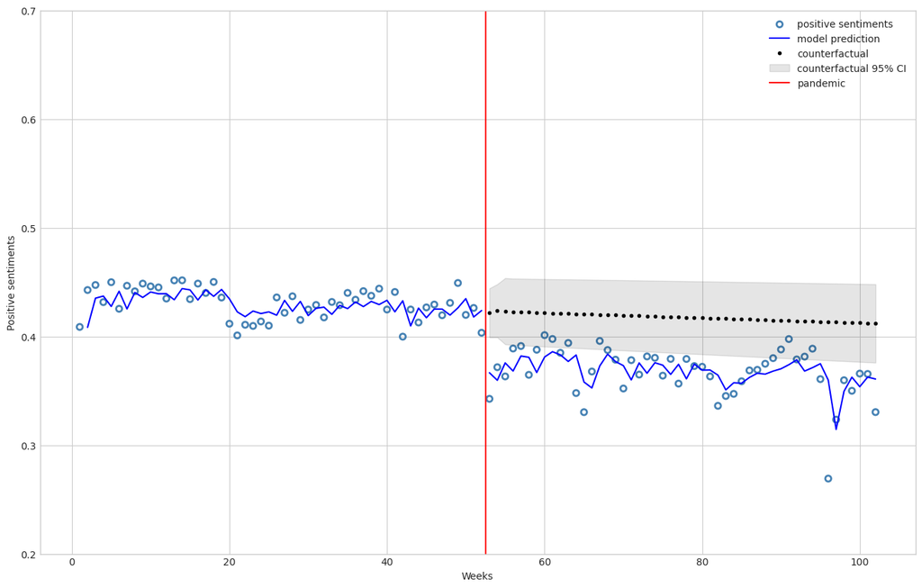

```python
start = 52
end = 102

# get the model predictions for the whole time period (start till end)
predictions = arima_results_om.get_prediction(0, end-1)
summary = predictions.summary_frame(alpha=0.025)

# get the counterfactual ARIMA by fitting a model only for the first time period (before the pandemic)
arima_cf = ARIMA(df_om["Y"][:start], df_om["T"][:start], order=(0,1,4)).fit()

# model predictions means
y_pred = predictions.predicted_mean

# counterfactual mean and 95% confidence interval
y_cf = arima_cf.get_forecast(50, exog=df_om["T"][start:]).summary_frame(alpha=0.05)

# plot section
plt.style.use('seaborn-v0_8-whitegrid')
fig, ax = plt.subplots(figsize=(16,10))

# plot weekly sentiment data
ax.scatter(df_om["T"], df_om["Y"], facecolors='none', edgecolors='steelblue', label="positive sentiments", linewidths=2)

# plot model mean sentiment prediction
ax.plot(df_om["T"][1:start], y_pred[1:start], 'b-', label="model prediction")
ax.plot(df_om["T"][start:], y_pred[start:], 'b-')

# plot counterfactual mean sentiment with 95% confidence interval
ax.plot(df_om["T"][start:], y_cf["mean"], 'k.', label="counterfactual")
ax.fill_between(df_om["T"][start:], y_cf['mean_ci_lower'], y_cf['mean_ci_upper'], color='k', alpha=0.1, label="counterfactual 95% CI")


# plot line marking the week of the official start of the pandemic (WHO)
ax.axvline(x = 52.5, color = 'r', label = 'pandemic')

ax.legend(loc='best')
plt.ylim([0.2, 0.7])
plt.xlabel("Weeks")
plt.ylabel("Positive sentiments")
```

### pos, original tweets - female vs. male

```python
from scipy import stats

# coefficient estimates (ARIMA) and standard errors (estimated via bootstrapping) from the two models
beta_of = -0.0607
se_of = 0.0137
beta_om = -0.0445
se_om = 0.0098

# calculate the Wald test statistic
wald_statistic = ((beta_of - beta_om) ** 2) / (se_of ** 2 + se_om ** 2)

# calculate the p-value
p_val = 1 - stats.chi2.cdf(wald_statistic, df=1) # 1 degree of freedom

# print the results
print(f"Wald Test Statistic: {wald_statistic}")
print(f"P-value: {p_val}")

# check if the coefficients are significantly different
if p_val < 0.05:
    print("Reject the null hypothesis: Coefficients are significantly different.")
else:
    print("Fail to reject the null hypothesis: Coefficients are not significantly different.")
```

```
Wald Test Statistic: 0.9249638741056637
P-value: 0.3361749876072324
Fail to reject the null hypothesis: Coefficients are not significantly different.
```

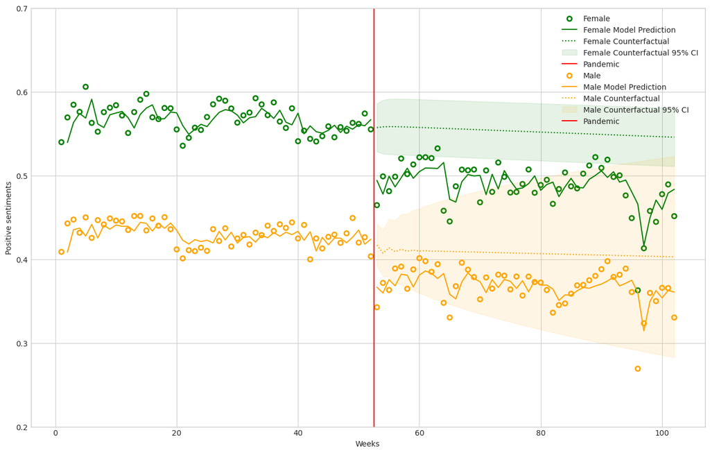

```python
# Define a function to generate the ARIMA plots
def generate_arima_plot(ax, df, arima_results, color, label):
    start = 52
    end = 102

    # get the model predictions for the whole time period (start till end)
    predictions = arima_results.get_prediction(0, end-1)

    # get the counterfactual ARIMA by fitting a model only for the first time period (before the pandemic)
    arima_cf = ARIMA(df["Y"][:start], df["T"][:start], order=(1,1,1)).fit()

    # model predictions means
    y_pred = predictions.predicted_mean

    # counterfactual mean and 95% confidence interval
    y_cf = arima_cf.get_forecast(50, exog=df["T"][start:]).summary_frame(alpha=0.05)

    # plot weekly sentiment data
    ax.scatter(df["T"], df["Y"], facecolors='none', edgecolors=color, label=label, linewidths=2)

    # plot model mean sentiment prediction
    ax.plot(df["T"][1:start], y_pred[1:start], color=color, linestyle='-', label=f"{label} Model Prediction")
    ax.plot(df["T"][start:], y_pred[start:], color=color, linestyle='-')

    # plot counterfactual mean sentiment with 95% confidence interval
    ax.plot(df["T"][start:], y_cf["mean"], color=color, linestyle='dotted', label=f"{label} Counterfactual")
    ax.fill_between(df["T"][start:], y_cf['mean_ci_lower'], y_cf['mean_ci_upper'], color=color, alpha=0.1, label=f"{label} Counterfactual 95% CI")

    # plot line marking the week of the official start of the pandemic (WHO)
    ax.axvline(x=52.5, color='r', label='Pandemic')

    ax.set_ylim([0.2, 0.7])
    ax.set_xlabel("Weeks")
    ax.set_ylabel("Positive sentiments")
    ax.legend(loc='best')

# Create a single plot
fig, ax = plt.subplots(figsize=(16, 10))

# Generate the first plot (female data) in green
generate_arima_plot(ax, df_of, arima_results_of, color='green', label='Female')

# Generate the second plot (male data) in orange
generate_arima_plot(ax, df_om, arima_results_om, color='orange', label='Male')

# Show the combined plot
plt.show()
```

## H2: POSITIVE SENTIMENTS - conversational tweets

```python
# define dfs
Y = df_reply_h2_f["pos_sent"]
T = df_reply_h2_f["week_T"]
D = df_reply_h2_f["pandemic_D"]
df_rf = pd.DataFrame({"Y": Y, "T": T, "D": D})

Y = df_reply_h2_m["pos_sent"]
T = df_reply_h2_m["week_T"]
D = df_reply_h2_m["pandemic_D"]
df_rm = pd.DataFrame({"Y": Y, "T": T, "D": D})
```

### pos, conversational tweets - female

```python
# fit the ARIMA model automatically for conversational df
model = pm.auto_arima(df_rf["Y"], seasonal=False, trace=True)
```

```
Performing stepwise search to minimize aic
 ARIMA(2,1,2)(0,0,0)[0] intercept   : AIC=-519.052, Time=0.18 sec
 ARIMA(0,1,0)(0,0,0)[0] intercept   : AIC=-503.600, Time=0.03 sec
 ARIMA(1,1,0)(0,0,0)[0] intercept   : AIC=-511.689, Time=0.03 sec
 ARIMA(0,1,1)(0,0,0)[0] intercept   : AIC=-515.538, Time=0.04 sec
 ARIMA(0,1,0)(0,0,0)[0]             : AIC=-505.375, Time=0.02 sec
 ARIMA(1,1,2)(0,0,0)[0] intercept   : AIC=-521.210, Time=0.14 sec
 ARIMA(0,1,2)(0,0,0)[0] intercept   : AIC=-520.110, Time=0.14 sec
 ARIMA(1,1,1)(0,0,0)[0] intercept   : AIC=-523.025, Time=0.10 sec
 ARIMA(2,1,1)(0,0,0)[0] intercept   : AIC=-510.884, Time=0.06 sec
 ARIMA(2,1,0)(0,0,0)[0] intercept   : AIC=-512.855, Time=0.03 sec
 ARIMA(1,1,1)(0,0,0)[0]             : AIC=-520.491, Time=0.05 sec

Best model:  ARIMA(1,1,1)(0,0,0)[0] intercept
Total fit time: 0.841 seconds
```

```python
# specify ARIMA model using the proposed parameters
arima_results_rf = ARIMA(df_rf["Y"], df_rf[["T", "D"]], order=(1,1,1)).fit()
print(arima_results_rf.summary(alpha=0.025))
```

```
                               SARIMAX Results
==============================================================================
Dep. Variable:                      Y   No. Observations:                  102
Model:                 ARIMA(1, 1, 1)   Log Likelihood                 267.694
Date:                Wed, 23 Oct 2024   AIC                           -525.388
Time:                        06:48:20   BIC                           -512.312
Sample:                    03-17-2019   HQIC                          -520.094
                         - 02-21-2021
Covariance Type:                  opg
==============================================================================
                 coef    std err          z      P>|z|     [0.0125     0.9875]
------------------------------------------------------------------------------
T             -0.0006      0.000     -1.490      0.136      -0.002       0.000
D             -0.0271      0.009     -2.891      0.004      -0.048      -0.006
ar.L1          0.4374      0.122      3.590      0.000       0.164       0.711
ma.L1         -0.9008      0.074    -12.226      0.000      -1.066      -0.736
sigma2         0.0003   3.43e-05      8.423      0.000       0.000       0.000
===================================================================================
Ljung-Box (L1) (Q):                   0.09   Jarque-Bera (JB):                20.91
Prob(Q):                              0.77   Prob(JB):                         0.00
Heteroskedasticity (H):               1.51   Skew:                            -0.78
Prob(H) (two-sided):                  0.23   Kurtosis:                         4.60
===================================================================================

Warnings:
[1] Covariance matrix calculated using the outer product of gradients (complex-step).
```

```python
# Define the number of bootstrap samples
n_bootstrap_samples = 1000
coefficient_D_estimates = []

# Set the random seed for reproducibility
np.random.seed(42)

# Define the block size for block bootstrapping
block_size = 3  # how many segments of data are resampled together (I need a quite small block size to capture short-term variation (effect of the start of the pandemic))

# Perform block bootstrapping
for _ in range(n_bootstrap_samples):
    # Generate a bootstrap sample of 'Y' and 'D' using block bootstrapping
    bootstrap_indices = np.random.randint(1, len(df_rf) - block_size, len(df_rf) // block_size)
    bootstrap_indices = np.repeat(bootstrap_indices, block_size) + np.tile(np.arange(block_size), len(bootstrap_indices))
    bootstrap_sample = df_rf.iloc[bootstrap_indices]

    # Fit ARIMA model to the bootstrap sample
    bootstrap_model = ARIMA(bootstrap_sample["Y"], bootstrap_sample[["T", "D"]], order=(1, 1, 1)).fit()

    # Store the estimated coefficient for 'D'
    coefficient_D_estimates.append(bootstrap_model.params["D"])

# Calculate standard errors and confidence intervals for the coefficient of 'D'
coefficient_D_estimates = np.array(coefficient_D_estimates)
coefficient_D_std_error = coefficient_D_estimates.std()
coefficient_D_ci_lower = np.percentile(coefficient_D_estimates, 1.25)
coefficient_D_ci_upper = np.percentile(coefficient_D_estimates, 98.75)

# Print the results
print("Bootstrap Standard Error for Coefficient of 'D':", coefficient_D_std_error)
print("Bootstrap 97.5% Confidence Interval for Coefficient of 'D':")
print("Lower Bound:", coefficient_D_ci_lower)
print("Upper Bound:", coefficient_D_ci_upper)
```

```
Bootstrap Standard Error for Coefficient of 'D': 0.01402833832918941
Bootstrap 97.5% Confidence Interval for Coefficient of 'D':
Lower Bound: -0.045218822254315796
Upper Bound: 0.018251106958445253
```

```
Bootstrap Standard Error for Coefficient of 'D': 0.01402833832918941
Bootstrap 97.5% Confidence Interval for Coefficient of 'D':
Lower Bound: -0.045218822254315796
Upper Bound: 0.018251106958445253
```

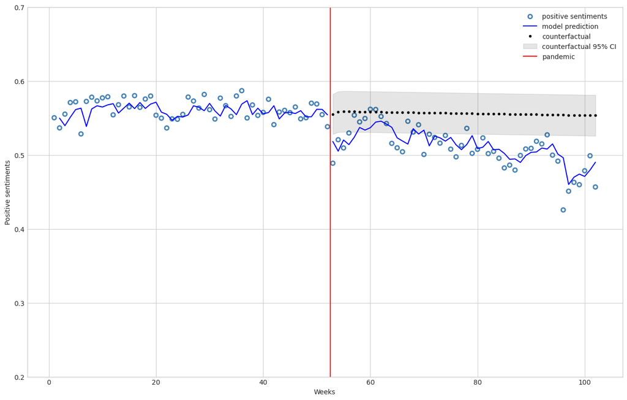

```python
start = 52
end = 102

# get the model predictions for the whole time period (start till end)
predictions = arima_results_rf.get_prediction(0, end-1)
summary = predictions.summary_frame(alpha=0.025)

# get the counterfactual ARIMA by fitting a model only for the first time period (before the pandemic)
arima_cf = ARIMA(df_rf["Y"][:start], df_rf["T"][:start], order=(1,1,1)).fit()

# model predictions means
y_pred = predictions.predicted_mean

# counterfactual mean and 95% confidence interval
y_cf = arima_cf.get_forecast(50, exog=df_rf["T"][start:]).summary_frame(alpha=0.05)

# plot section
plt.style.use('seaborn-v0_8-whitegrid')
fig, ax = plt.subplots(figsize=(16,10))

# plot weekly sentiment data
ax.scatter(df_rf["T"], df_rf["Y"], facecolors='none', edgecolors='steelblue', label="positive sentiments", linewidths=2)

# plot model mean sentiment prediction
ax.plot(df_rf["T"][1:start], y_pred[1:start], 'b-', label="model prediction")
ax.plot(df_rf["T"][start:], y_pred[start:], 'b-')

# plot counterfactual mean sentiment with 95% confidence interval
ax.plot(df_rf["T"][start:], y_cf["mean"], 'k.', label="counterfactual")
ax.fill_between(df_rf["T"][start:], y_cf['mean_ci_lower'], y_cf['mean_ci_upper'], color='k', alpha=0.1, label="counterfactual 95% CI")


# plot line marking the week of the official start of the pandemic (WHO)
ax.axvline(x = 52.5, color = 'r', label = 'pandemic')

ax.legend(loc='best')
plt.ylim([0.2, 0.7])
plt.xlabel("Weeks")
plt.ylabel("Positive sentiments")
```

### pos, conversational tweets - male

```python
# fit the ARIMA model automatically for conversational df
model = pm.auto_arima(df_rm["Y"], seasonal=False, trace=True)
```

```
Performing stepwise search to minimize aic
 ARIMA(2,1,2)(0,0,0)[0] intercept   : AIC=-535.723, Time=0.06 sec
 ARIMA(0,1,0)(0,0,0)[0] intercept   : AIC=-510.223, Time=0.03 sec
 ARIMA(1,1,0)(0,0,0)[0] intercept   : AIC=-513.179, Time=0.05 sec
 ARIMA(0,1,1)(0,0,0)[0] intercept   : AIC=-529.900, Time=0.06 sec
 ARIMA(0,1,0)(0,0,0)[0]             : AIC=-512.138, Time=0.04 sec
 ARIMA(1,1,2)(0,0,0)[0] intercept   : AIC=-538.716, Time=0.13 sec
 ARIMA(0,1,2)(0,0,0)[0] intercept   : AIC=-539.169, Time=0.07 sec
 ARIMA(0,1,3)(0,0,0)[0] intercept   : AIC=-538.403, Time=0.11 sec
 ARIMA(1,1,1)(0,0,0)[0] intercept   : AIC=inf, Time=0.13 sec
 ARIMA(1,1,3)(0,0,0)[0] intercept   : AIC=-536.449, Time=0.17 sec
 ARIMA(0,1,2)(0,0,0)[0]             : AIC=-537.804, Time=0.07 sec

Best model:  ARIMA(0,1,2)(0,0,0)[0] intercept
Total fit time: 0.917 seconds
```

```python
# specify ARIMA model using the proposed parameters
arima_results_rm = ARIMA(df_rm["Y"], df_rm[["T", "D"]], order=(2,1,1)).fit()
print(arima_results_rm.summary(alpha=0.025))
```

```
                               SARIMAX Results
==============================================================================
Dep. Variable:                      Y   No. Observations:                  102
Model:                 ARIMA(2, 1, 1)   Log Likelihood                 276.188
Date:                Wed, 23 Oct 2024   AIC                           -540.377
Time:                        06:49:59   BIC                           -524.686
Sample:                    03-17-2019   HQIC                          -534.025
                         - 02-21-2021
Covariance Type:                  opg
==============================================================================
                 coef    std err          z      P>|z|     [0.0125     0.9875]
------------------------------------------------------------------------------
T             -0.0003      0.000     -1.160      0.246      -0.001       0.000
D             -0.0187      0.011     -1.757      0.079      -0.043       0.005
ar.L1          0.3348      0.112      2.986      0.003       0.084       0.586
ar.L2         -0.1894      0.142     -1.333      0.182      -0.508       0.129
ma.L1         -0.8943      0.091     -9.866      0.000      -1.097      -0.691
sigma2         0.0002    3.8e-05      6.403      0.000       0.000       0.000
===================================================================================
Ljung-Box (L1) (Q):                   0.00   Jarque-Bera (JB):                12.16
Prob(Q):                              0.97   Prob(JB):                         0.00
Heteroskedasticity (H):               1.39   Skew:                            -0.77
Prob(H) (two-sided):                  0.35   Kurtosis:                         3.70
===================================================================================

Warnings:
[1] Covariance matrix calculated using the outer product of gradients (complex-step).
```

```python
# Define the number of bootstrap samples
n_bootstrap_samples = 1000
coefficient_D_estimates = []

# Set the random seed for reproducibility
np.random.seed(42)

# Define the block size for block bootstrapping
block_size = 3  # how many segments of data are resampled together (I need a quite small block size to capture short-term variation (effect of the start of the pandemic))

# Perform block bootstrapping
for _ in range(n_bootstrap_samples):
    # Generate a bootstrap sample of 'Y' and 'D' using block bootstrapping
    bootstrap_indices = np.random.randint(1, len(df_rm) - block_size, len(df_rm) // block_size)
    bootstrap_indices = np.repeat(bootstrap_indices, block_size) + np.tile(np.arange(block_size), len(bootstrap_indices))
    bootstrap_sample = df_rm.iloc[bootstrap_indices]

    # Fit ARIMA model to the bootstrap sample
    bootstrap_model = ARIMA(bootstrap_sample["Y"], bootstrap_sample[["T", "D"]], order=(2, 1, 1)).fit()

    # Store the estimated coefficient for 'D'
    coefficient_D_estimates.append(bootstrap_model.params["D"])

# Calculate standard errors and confidence intervals for the coefficient of 'D'
coefficient_D_estimates = np.array(coefficient_D_estimates)
coefficient_D_std_error = coefficient_D_estimates.std()
coefficient_D_ci_lower = np.percentile(coefficient_D_estimates, 1.25)
coefficient_D_ci_upper = np.percentile(coefficient_D_estimates, 98.75)

# Print the results
print("Bootstrap Standard Error for Coefficient of 'D':", coefficient_D_std_error)
print("Bootstrap 97.5% Confidence Interval for Coefficient of 'D':")
print("Lower Bound:", coefficient_D_ci_lower)
print("Upper Bound:", coefficient_D_ci_upper)
```

```
Bootstrap Standard Error for Coefficient of 'D': 0.009520508774451803
Bootstrap 97.5% Confidence Interval for Coefficient of 'D':
Lower Bound: -0.04178177845338513
Upper Bound: 0.0026613587597724866
```

```
Bootstrap Standard Error for Coefficient of 'D': 0.009520508774451803
Bootstrap 97.5% Confidence Interval for Coefficient of 'D':
Lower Bound: -0.04178177845338513
Upper Bound: 0.0026613587597724866
```

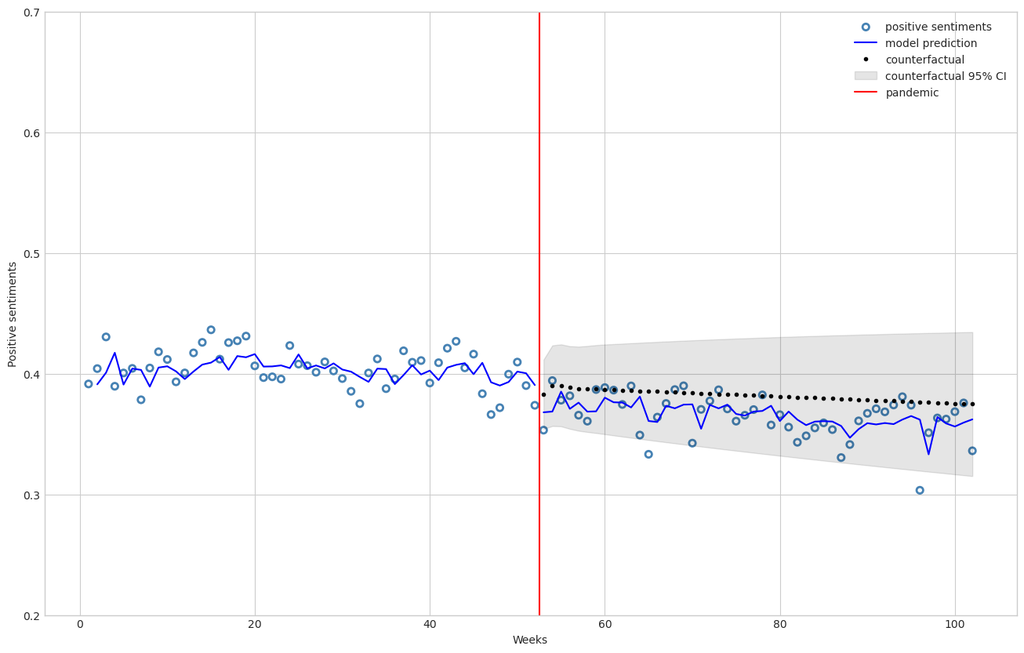

```python
start = 52
end = 102

# get the model predictions for the whole time period (start till end)
predictions = arima_results_rm.get_prediction(0, end-1)
summary = predictions.summary_frame(alpha=0.025)

# get the counterfactual ARIMA by fitting a model only for the first time period (before the pandemic)
arima_cf = ARIMA(df_rm["Y"][:start], df_rm["T"][:start], order=(2,1,1)).fit()

# model predictions means
y_pred = predictions.predicted_mean

# counterfactual mean and 95% confidence interval
y_cf = arima_cf.get_forecast(50, exog=df_rm["T"][start:]).summary_frame(alpha=0.05)

# plot section
plt.style.use('seaborn-v0_8-whitegrid')
fig, ax = plt.subplots(figsize=(16,10))

# plot weekly sentiment data
ax.scatter(df_rm["T"], df_rm["Y"], facecolors='none', edgecolors='steelblue', label="positive sentiments", linewidths=2)

# plot model mean sentiment prediction
ax.plot(df_rm["T"][1:start], y_pred[1:start], 'b-', label="model prediction")
ax.plot(df_rm["T"][start:], y_pred[start:], 'b-')

# plot counterfactual mean sentiment with 95% confidence interval
ax.plot(df_rm["T"][start:], y_cf["mean"], 'k.', label="counterfactual")
ax.fill_between(df_rm["T"][start:], y_cf['mean_ci_lower'], y_cf['mean_ci_upper'], color='k', alpha=0.1, label="counterfactual 95% CI")


# plot line marking the week of the official start of the pandemic (WHO)
ax.axvline(x = 52.5, color = 'r', label = 'pandemic')

ax.legend(loc='best')
plt.ylim([0.2, 0.7])
plt.xlabel("Weeks")
plt.ylabel("Positive sentiments")
```

### pos, conversational tweets - female vs. male

```python
# coefficient estimates (ARIMA) and standard errors (estimated via bootstrapping) from the two models
beta_rf = -0.0271
se_rf = 0.0140
beta_rm = -0.0187
se_rm = 0.0095

# calculate the Wald test statistic
wald_statistic = ((beta_rf - beta_rm) ** 2) / (se_rf ** 2 + se_rm ** 2)

# calculate the p-value
p_val = 1 - stats.chi2.cdf(wald_statistic, df=1) # 1 degree of freedom

# print the results
print(f"Wald Test Statistic: {wald_statistic}")
print(f"P-value: {p_val}")

# check if the coefficients are significantly different
if p_val < 0.05:
    print("Reject the null hypothesis: Coefficients are significantly different.")
else:
    print("Fail to reject the null hypothesis: Coefficients are not significantly different.")
```

```
Wald Test Statistic: 0.24649781659388628
P-value: 0.6195519400564914
Fail to reject the null hypothesis: Coefficients are not significantly different.
```

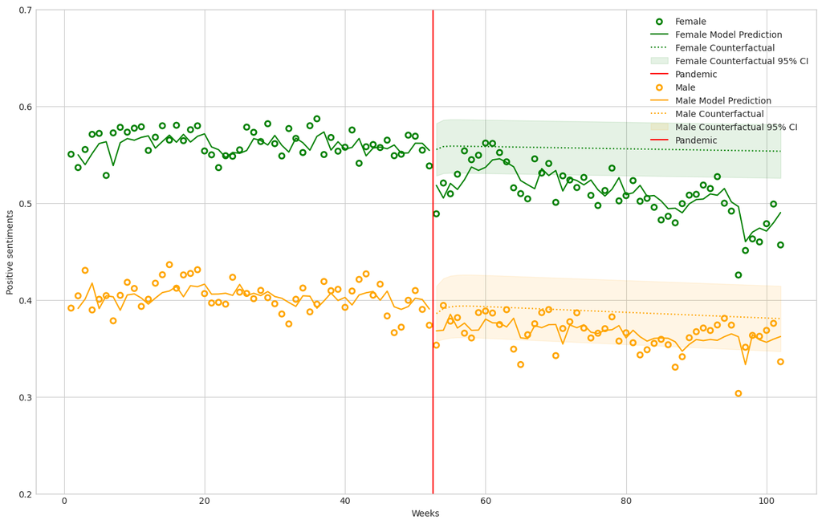

```python
# Define a function to generate the ARIMA plots
def generate_arima_plot(ax, df, arima_results, color, label):
    start = 52
    end = 102

    # get the model predictions for the whole time period (start till end)
    predictions = arima_results.get_prediction(0, end-1)

    # get the counterfactual ARIMA by fitting a model only for the first time period (before the pandemic)
    arima_cf = ARIMA(df["Y"][:start], df["T"][:start], order=(1,1,1)).fit()

    # model predictions means
    y_pred = predictions.predicted_mean

    # counterfactual mean and 95% confidence interval
    y_cf = arima_cf.get_forecast(50, exog=df["T"][start:]).summary_frame(alpha=0.05)

    # plot weekly sentiment data
    ax.scatter(df["T"], df["Y"], facecolors='none', edgecolors=color, label=label, linewidths=2)

    # plot model mean sentiment prediction
    ax.plot(df["T"][1:start], y_pred[1:start], color=color, linestyle='-', label=f"{label} Model Prediction")
    ax.plot(df["T"][start:], y_pred[start:], color=color, linestyle='-')

    # plot counterfactual mean sentiment with 95% confidence interval
    ax.plot(df["T"][start:], y_cf["mean"], color=color, linestyle='dotted', label=f"{label} Counterfactual")
    ax.fill_between(df["T"][start:], y_cf['mean_ci_lower'], y_cf['mean_ci_upper'], color=color, alpha=0.1, label=f"{label} Counterfactual 95% CI")

    # plot line marking the week of the official start of the pandemic (WHO)
    ax.axvline(x=52.5, color='r', label='Pandemic')

    ax.set_ylim([0.2, 0.7])
    ax.set_xlabel("Weeks")
    ax.set_ylabel("Positive sentiments")
    ax.legend(loc='best')

# Create a single plot
fig, ax = plt.subplots(figsize=(16, 10))

# Generate the first plot (female data) in green
generate_arima_plot(ax, df_rf, arima_results_rf, color='green', label='Female')

# Generate the second plot (male data) in orange
generate_arima_plot(ax, df_rm, arima_results_rm, color='orange', label='Male')

# Show the combined plot
plt.show()
```

## H2: NEGATIVE SENTIMENTS - original tweets

```python
# define dfs
Y = df_orig_h2_f["neg_sent"]
T = df_orig_h2_f["week_T"]
D = df_orig_h2_f["pandemic_D"]
df_of = pd.DataFrame({"Y": Y, "T": T, "D": D})

Y = df_orig_h2_m["neg_sent"]
T = df_orig_h2_m["week_T"]
D = df_orig_h2_m["pandemic_D"]
df_om = pd.DataFrame({"Y": Y, "T": T, "D": D})
```

### neg, original tweets - female

```python
# fit the ARIMA model automatically for original df
model = pm.auto_arima(df_of["Y"], seasonal=False, trace=True)
```

```
Performing stepwise search to minimize aic
 ARIMA(2,1,2)(0,0,0)[0] intercept   : AIC=-550.516, Time=0.26 sec
 ARIMA(0,1,0)(0,0,0)[0] intercept   : AIC=-535.306, Time=0.03 sec
 ARIMA(1,1,0)(0,0,0)[0] intercept   : AIC=-538.984, Time=0.03 sec
 ARIMA(0,1,1)(0,0,0)[0] intercept   : AIC=-541.639, Time=0.04 sec
 ARIMA(0,1,0)(0,0,0)[0]             : AIC=-537.152, Time=0.01 sec
 ARIMA(1,1,2)(0,0,0)[0] intercept   : AIC=-542.381, Time=0.12 sec
 ARIMA(2,1,1)(0,0,0)[0] intercept   : AIC=-540.505, Time=0.16 sec
 ARIMA(3,1,2)(0,0,0)[0] intercept   : AIC=-548.104, Time=0.19 sec
 ARIMA(2,1,3)(0,0,0)[0] intercept   : AIC=-545.770, Time=0.14 sec
 ARIMA(1,1,1)(0,0,0)[0] intercept   : AIC=inf, Time=0.11 sec
 ARIMA(1,1,3)(0,0,0)[0] intercept   : AIC=-542.144, Time=0.07 sec
 ARIMA(3,1,1)(0,0,0)[0] intercept   : AIC=-536.978, Time=0.10 sec
 ARIMA(3,1,3)(0,0,0)[0] intercept   : AIC=-548.960, Time=0.19 sec
 ARIMA(2,1,2)(0,0,0)[0]             : AIC=-545.000, Time=0.07 sec

Best model:  ARIMA(2,1,2)(0,0,0)[0] intercept
Total fit time: 1.523 seconds
```

```python
# specify ARIMA model using the proposed parameters
arima_results_of = ARIMA(df_of["Y"], df_of[["T", "D"]], order=(2,1,2)).fit()
print(arima_results_of.summary(alpha=0.025))
```

```
                               SARIMAX Results
==============================================================================
Dep. Variable:                      Y   No. Observations:                  102
Model:                 ARIMA(2, 1, 2)   Log Likelihood                 283.394
Date:                Wed, 23 Oct 2024   AIC                           -552.788
Time:                        07:17:56   BIC                           -534.482
Sample:                    03-17-2019   HQIC                          -545.377
                         - 02-21-2021
Covariance Type:                  opg
==============================================================================
                 coef    std err          z      P>|z|     [0.0125     0.9875]
------------------------------------------------------------------------------
T              0.0006      0.000      1.544      0.123      -0.000       0.001
D              0.0252      0.014      1.808      0.071      -0.006       0.057
ar.L1         -0.2924      0.308     -0.948      0.343      -0.984       0.399
ar.L2          0.4263      0.226      1.883      0.060      -0.081       0.934
ma.L1         -0.0469      0.223     -0.211      0.833      -0.546       0.452
ma.L2         -0.8478      0.211     -4.025      0.000      -1.320      -0.376
sigma2         0.0002   2.17e-05      9.765      0.000       0.000       0.000
===================================================================================
Ljung-Box (L1) (Q):                   0.56   Jarque-Bera (JB):               603.84
Prob(Q):                              0.45   Prob(JB):                         0.00
Heteroskedasticity (H):               4.20   Skew:                             2.44
Prob(H) (two-sided):                  0.00   Kurtosis:                        13.94
===================================================================================

Warnings:
[1] Covariance matrix calculated using the outer product of gradients (complex-step).
```

```python
# Define the number of bootstrap samples
n_bootstrap_samples = 1000
coefficient_D_estimates = []

# Set the random seed for reproducibility
np.random.seed(42)

# Define the block size for block bootstrapping
block_size = 3  # how many segments of data are resampled together (I need a quite small block size to capture short-term variation (effect of the start of the pandemic))

# Perform block bootstrapping
for _ in range(n_bootstrap_samples):
    # Generate a bootstrap sample of 'Y' and 'D' using block bootstrapping
    bootstrap_indices = np.random.randint(1, len(df_of) - block_size, len(df_of) // block_size)
    bootstrap_indices = np.repeat(bootstrap_indices, block_size) + np.tile(np.arange(block_size), len(bootstrap_indices))
    bootstrap_sample = df_of.iloc[bootstrap_indices]

    # Fit ARIMA model to the bootstrap sample
    bootstrap_model = ARIMA(bootstrap_sample["Y"], bootstrap_sample[["T", "D"]], order=(2, 1, 2)).fit()

    # Store the estimated coefficient for 'D'
    coefficient_D_estimates.append(bootstrap_model.params["D"])

# Calculate standard errors and confidence intervals for the coefficient of 'D'
coefficient_D_estimates = np.array(coefficient_D_estimates)
coefficient_D_std_error = coefficient_D_estimates.std()
coefficient_D_ci_lower = np.percentile(coefficient_D_estimates, 1.25)
coefficient_D_ci_upper = np.percentile(coefficient_D_estimates, 98.75)

# Print the results
print("Bootstrap Standard Error for Coefficient of 'D':", coefficient_D_std_error)
print("Bootstrap 97.5% Confidence Interval for Coefficient of 'D':")
print("Lower Bound:", coefficient_D_ci_lower)
print("Upper Bound:", coefficient_D_ci_upper)
```

```
Bootstrap Standard Error for Coefficient of 'D': 0.010914781827917535
Bootstrap 97.5% Confidence Interval for Coefficient of 'D':
Lower Bound: -0.009142108572818148
Upper Bound: 0.039741856249821794
```

```
Bootstrap Standard Error for Coefficient of 'D': 0.010914781827917535
Bootstrap 97.5% Confidence Interval for Coefficient of 'D':
Lower Bound: -0.009142108572818148
Upper Bound: 0.039741856249821794
```

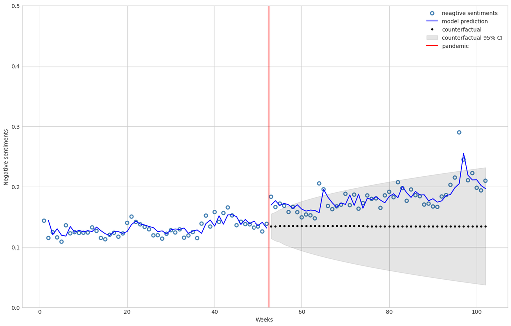

```python
start = 52
end = 102

# get the model predictions for the whole time period (start till end)
predictions = arima_results_of.get_prediction(0, end-1)
summary = predictions.summary_frame(alpha=0.025)

# get the counterfactual ARIMA by fitting a model only for the first time period (before the pandemic)
arima_cf = ARIMA(df_of["Y"][:start], df_of["T"][:start], order=(2,1,2)).fit()

# model predictions means
y_pred = predictions.predicted_mean

# counterfactual mean and 95% confidence interval
y_cf = arima_cf.get_forecast(50, exog=df_of["T"][start:]).summary_frame(alpha=0.05)

# plot section
plt.style.use('seaborn-v0_8-whitegrid')
fig, ax = plt.subplots(figsize=(16,10))

# plot weekly sentiment data
ax.scatter(df_of["T"], df_of["Y"], facecolors='none', edgecolors='steelblue', label="neagtive sentiments", linewidths=2)

# plot model mean sentiment prediction
ax.plot(df_of["T"][1:start], y_pred[1:start], 'b-', label="model prediction")
ax.plot(df_of["T"][start:], y_pred[start:], 'b-')

# plot counterfactual mean sentiment with 95% confidence interval
ax.plot(df_of["T"][start:], y_cf["mean"], 'k.', label="counterfactual")
ax.fill_between(df_of["T"][start:], y_cf['mean_ci_lower'], y_cf['mean_ci_upper'], color='k', alpha=0.1, label="counterfactual 95% CI")


# plot line marking the week of the official start of the pandemic (WHO)
ax.axvline(x = 52.5, color = 'r', label = 'pandemic')

ax.legend(loc='best')
plt.ylim([0, 0.5])
plt.xlabel("Weeks")
plt.ylabel("Negative sentiments")
```

### neg, original tweets - male

```python
# fit the ARIMA model automatically for original df
model = pm.auto_arima(df_om["Y"], seasonal=False, trace=True)
```

```
Performing stepwise search to minimize aic
 ARIMA(2,1,2)(0,0,0)[0] intercept   : AIC=-533.889, Time=0.19 sec
 ARIMA(0,1,0)(0,0,0)[0] intercept   : AIC=-516.081, Time=0.02 sec
 ARIMA(1,1,0)(0,0,0)[0] intercept   : AIC=-517.571, Time=0.04 sec
 ARIMA(0,1,1)(0,0,0)[0] intercept   : AIC=-520.856, Time=0.06 sec
 ARIMA(0,1,0)(0,0,0)[0]             : AIC=-517.838, Time=0.02 sec
 ARIMA(1,1,2)(0,0,0)[0] intercept   : AIC=-535.043, Time=0.11 sec
 ARIMA(0,1,2)(0,0,0)[0] intercept   : AIC=-536.165, Time=0.09 sec
 ARIMA(0,1,3)(0,0,0)[0] intercept   : AIC=-534.063, Time=0.06 sec
 ARIMA(1,1,1)(0,0,0)[0] intercept   : AIC=-536.137, Time=0.07 sec
 ARIMA(1,1,3)(0,0,0)[0] intercept   : AIC=-532.358, Time=0.08 sec
 ARIMA(0,1,2)(0,0,0)[0]             : AIC=-530.953, Time=0.05 sec

Best model:  ARIMA(0,1,2)(0,0,0)[0] intercept
Total fit time: 0.776 seconds
```

```python
# specify ARIMA model using the proposed parameters
arima_results_om = ARIMA(df_om["Y"], df_om[["T", "D"]], order=(0,1,2)).fit()
print(arima_results_om.summary(alpha=0.025))
```

```
                               SARIMAX Results
==============================================================================
Dep. Variable:                      Y   No. Observations:                  102
Model:                 ARIMA(0, 1, 2)   Log Likelihood                 276.419
Date:                Wed, 23 Oct 2024   AIC                           -542.837
Time:                        09:03:12   BIC                           -529.762
Sample:                    03-17-2019   HQIC                          -537.544
                         - 02-21-2021
Covariance Type:                  opg
==============================================================================
                 coef    std err          z      P>|z|     [0.0125     0.9875]
------------------------------------------------------------------------------
T              0.0006      0.000      3.092      0.002       0.000       0.001
D              0.0274      0.012      2.348      0.019       0.001       0.054
ma.L1         -0.5475      0.132     -4.158      0.000      -0.843      -0.252
ma.L2         -0.4286      0.142     -3.023      0.002      -0.746      -0.111
sigma2         0.0002   2.93e-05      8.143      0.000       0.000       0.000
===================================================================================
Ljung-Box (L1) (Q):                   0.22   Jarque-Bera (JB):               706.89
Prob(Q):                              0.64   Prob(JB):                         0.00
Heteroskedasticity (H):               4.04   Skew:                             2.51
Prob(H) (two-sided):                  0.00   Kurtosis:                        14.95
===================================================================================

Warnings:
[1] Covariance matrix calculated using the outer product of gradients (complex-step).
```

```python
# Define the number of bootstrap samples
n_bootstrap_samples = 1000
coefficient_D_estimates = []

# Set the random seed for reproducibility
np.random.seed(42)

# Define the block size for block bootstrapping
block_size = 3  # how many segments of data are resampled together (I need a quite small block size to capture short-term variation (effect of the start of the pandemic))

# Perform block bootstrapping
for _ in range(n_bootstrap_samples):
    # Generate a bootstrap sample of 'Y' and 'D' using block bootstrapping
    bootstrap_indices = np.random.randint(1, len(df_om) - block_size, len(df_om) // block_size)
    bootstrap_indices = np.repeat(bootstrap_indices, block_size) + np.tile(np.arange(block_size), len(bootstrap_indices))
    bootstrap_sample = df_om.iloc[bootstrap_indices]

    # Fit ARIMA model to the bootstrap sample
    bootstrap_model = ARIMA(bootstrap_sample["Y"], bootstrap_sample[["T", "D"]], order=(0, 1, 2)).fit()

    # Store the estimated coefficient for 'D'
    coefficient_D_estimates.append(bootstrap_model.params["D"])

# Calculate standard errors and confidence intervals for the coefficient of 'D'
coefficient_D_estimates = np.array(coefficient_D_estimates)
coefficient_D_std_error = coefficient_D_estimates.std()
coefficient_D_ci_lower = np.percentile(coefficient_D_estimates, 1.25)
coefficient_D_ci_upper = np.percentile(coefficient_D_estimates, 98.75)

# Print the results
print("Bootstrap Standard Error for Coefficient of 'D':", coefficient_D_std_error)
print("Bootstrap 97.5% Confidence Interval for Coefficient of 'D':")
print("Lower Bound:", coefficient_D_ci_lower)
print("Upper Bound:", coefficient_D_ci_upper)
```

```
Bootstrap Standard Error for Coefficient of 'D': 0.00925503300103237
Bootstrap 97.5% Confidence Interval for Coefficient of 'D':
Lower Bound: 0.004541912092612658
Upper Bound: 0.04687848772263472
```

```
Bootstrap Standard Error for Coefficient of 'D': 0.00925503300103237
Bootstrap 97.5% Confidence Interval for Coefficient of 'D':
Lower Bound: 0.004541912092612658
Upper Bound: 0.04687848772263472
```

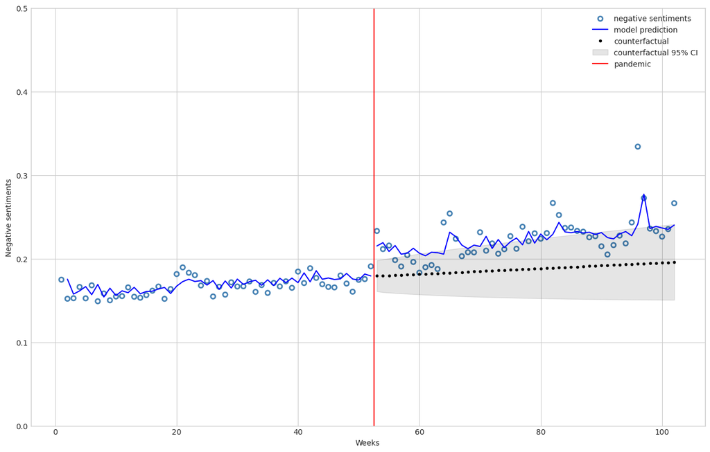

```python
start = 52
end = 102

# get the model predictions for the whole time period (start till end)
predictions = arima_results_om.get_prediction(0, end-1)
summary = predictions.summary_frame(alpha=0.025)

# get the counterfactual ARIMA by fitting a model only for the first time period (before the pandemic)
arima_cf = ARIMA(df_om["Y"][:start], df_om["T"][:start], order=(0,1,2)).fit()

# model predictions means
y_pred = predictions.predicted_mean

# counterfactual mean and 95% confidence interval
y_cf = arima_cf.get_forecast(50, exog=df_om["T"][start:]).summary_frame(alpha=0.05)

# plot section
plt.style.use('seaborn-v0_8-whitegrid')
fig, ax = plt.subplots(figsize=(16,10))

# plot weekly sentiment data
ax.scatter(df_om["T"], df_om["Y"], facecolors='none', edgecolors='steelblue', label="negative sentiments", linewidths=2)

# plot model mean sentiment prediction
ax.plot(df_om["T"][1:start], y_pred[1:start], 'b-', label="model prediction")
ax.plot(df_om["T"][start:], y_pred[start:], 'b-')

# plot counterfactual mean sentiment with 95% confidence interval
ax.plot(df_om["T"][start:], y_cf["mean"], 'k.', label="counterfactual")
ax.fill_between(df_om["T"][start:], y_cf['mean_ci_lower'], y_cf['mean_ci_upper'], color='k', alpha=0.1, label="counterfactual 95% CI")


# plot line marking the week of the official start of the pandemic (WHO)
ax.axvline(x = 52.5, color = 'r', label = 'pandemic')

ax.legend(loc='best')
plt.ylim([0, 0.5])
plt.xlabel("Weeks")
plt.ylabel("Negative sentiments")
```

### neg, original tweets - female vs. male

```python
# coefficient estimates (ARIMA) and standard errors (estimated via bootstrapping) from the two models
beta_of = 0.0252
se_of = 0.011
beta_om = 0.0274
se_om = 0.0093

# calculate the Wald test statistic
wald_statistic = ((beta_of - beta_om) ** 2) / (se_of ** 2 + se_om ** 2)

# calculate the p-value
p_val = 1 - stats.chi2.cdf(wald_statistic, df=1) # 1 degree of freedom

# print the results
print(f"Wald Test Statistic: {wald_statistic}")
print(f"P-value: {p_val}")

# check if the coefficients are significantly different
if p_val < 0.05:
    print("Reject the null hypothesis: Coefficients are significantly different.")
else:
    print("Fail to reject the null hypothesis: Coefficients are not significantly different.")
```

```
Wald Test Statistic: 0.023326425369897364
P-value: 0.8786112728062946
Fail to reject the null hypothesis: Coefficients are not significantly different.
```

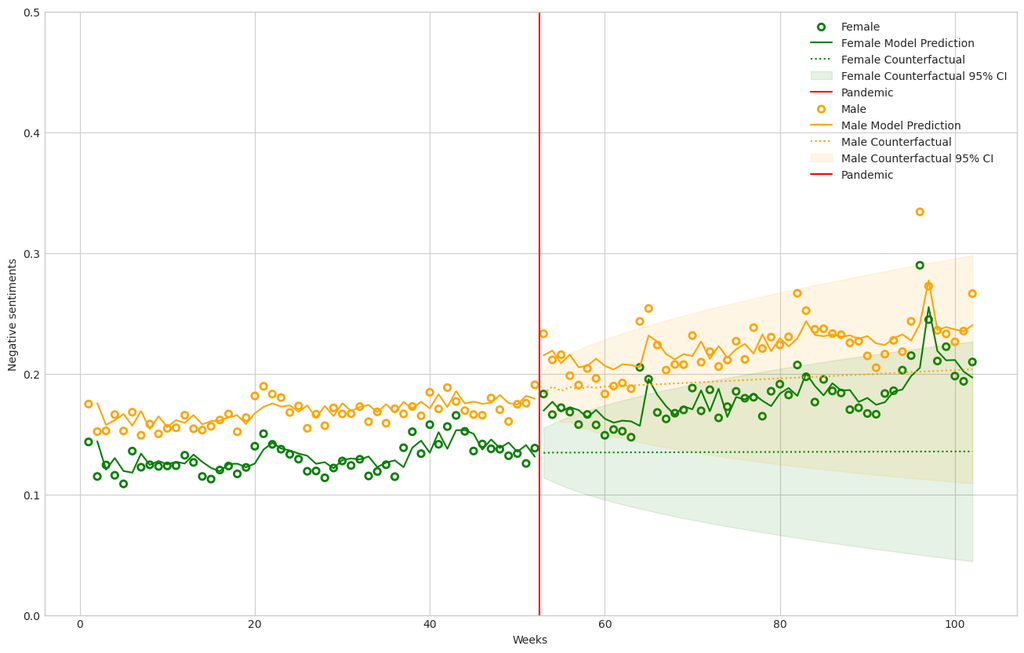

```python
# Define a function to generate the ARIMA plots
def generate_arima_plot(ax, df, arima_results, color, label):
    start = 52
    end = 102

    # get the model predictions for the whole time period (start till end)
    predictions = arima_results.get_prediction(0, end-1)

    # get the counterfactual ARIMA by fitting a model only for the first time period (before the pandemic)
    arima_cf = ARIMA(df["Y"][:start], df["T"][:start], order=(1,1,1)).fit()

    # model predictions means
    y_pred = predictions.predicted_mean

    # counterfactual mean and 95% confidence interval
    y_cf = arima_cf.get_forecast(50, exog=df["T"][start:]).summary_frame(alpha=0.05)

    # plot weekly sentiment data
    ax.scatter(df["T"], df["Y"], facecolors='none', edgecolors=color, label=label, linewidths=2)

    # plot model mean sentiment prediction
    ax.plot(df["T"][1:start], y_pred[1:start], color=color, linestyle='-', label=f"{label} Model Prediction")
    ax.plot(df["T"][start:], y_pred[start:], color=color, linestyle='-')

    # plot counterfactual mean sentiment with 95% confidence interval
    ax.plot(df["T"][start:], y_cf["mean"], color=color, linestyle='dotted', label=f"{label} Counterfactual")
    ax.fill_between(df["T"][start:], y_cf['mean_ci_lower'], y_cf['mean_ci_upper'], color=color, alpha=0.1, label=f"{label} Counterfactual 95% CI")

    # plot line marking the week of the official start of the pandemic (WHO)
    ax.axvline(x=52.5, color='r', label='Pandemic')

    ax.set_ylim([0, 0.5])
    ax.set_xlabel("Weeks")
    ax.set_ylabel("Negative sentiments")
    ax.legend(loc='best')

# Create a single plot
fig, ax = plt.subplots(figsize=(16, 10))

# Generate the first plot (female data) in green
generate_arima_plot(ax, df_of, arima_results_of, color='green', label='Female')

# Generate the second plot (male data) in orange
generate_arima_plot(ax, df_om, arima_results_om, color='orange', label='Male')

# Show the combined plot
plt.show()
```

## H2: NEGATIVE SENTIMENTS - conversational tweets

```python
# define dfs
Y = df_reply_h2_f["neg_sent"]
T = df_reply_h2_f["week_T"]
D = df_reply_h2_f["pandemic_D"]
df_rf = pd.DataFrame({"Y": Y, "T": T, "D": D})

Y = df_reply_h2_m["neg_sent"]
T = df_reply_h2_m["week_T"]
D = df_reply_h2_m["pandemic_D"]
df_rm = pd.DataFrame({"Y": Y, "T": T, "D": D})
```

### neg, conversational tweets - female

```python
# fit the ARIMA model automatically for conversational df
model = pm.auto_arima(df_rf["Y"], seasonal=False, trace=True)
```

```
Performing stepwise search to minimize aic
 ARIMA(2,1,2)(0,0,0)[0] intercept   : AIC=-601.731, Time=0.11 sec
 ARIMA(0,1,0)(0,0,0)[0] intercept   : AIC=-587.988, Time=0.03 sec
 ARIMA(1,1,0)(0,0,0)[0] intercept   : AIC=-591.249, Time=0.03 sec
 ARIMA(0,1,1)(0,0,0)[0] intercept   : AIC=-597.196, Time=0.05 sec
 ARIMA(0,1,0)(0,0,0)[0]             : AIC=-589.502, Time=0.02 sec
 ARIMA(1,1,2)(0,0,0)[0] intercept   : AIC=-604.924, Time=0.10 sec
 ARIMA(0,1,2)(0,0,0)[0] intercept   : AIC=-606.607, Time=0.08 sec
 ARIMA(0,1,3)(0,0,0)[0] intercept   : AIC=-603.941, Time=0.12 sec
 ARIMA(1,1,1)(0,0,0)[0] intercept   : AIC=-601.173, Time=0.07 sec
 ARIMA(1,1,3)(0,0,0)[0] intercept   : AIC=-602.810, Time=0.12 sec
 ARIMA(0,1,2)(0,0,0)[0]             : AIC=-603.159, Time=0.05 sec

Best model:  ARIMA(0,1,2)(0,0,0)[0] intercept
Total fit time: 0.792 seconds
```

```python
# specify ARIMA model using the proposed parameters
arima_results_rf = ARIMA(df_rf["Y"], df_rf[["T", "D"]], order=(0,1,2)).fit()
print(arima_results_rf.summary(alpha=0.025))
```

```
                               SARIMAX Results
==============================================================================
Dep. Variable:                      Y   No. Observations:                  102
Model:                 ARIMA(0, 1, 2)   Log Likelihood                 307.665
Date:                Wed, 23 Oct 2024   AIC                           -605.330
Time:                        09:21:07   BIC                           -592.255
Sample:                    03-17-2019   HQIC                          -600.037
                         - 02-21-2021
Covariance Type:                  opg
==============================================================================
                 coef    std err          z      P>|z|     [0.0125     0.9875]
------------------------------------------------------------------------------
T              0.0006      0.000      2.086      0.037   -4.79e-05       0.001
D              0.0072      0.010      0.748      0.454      -0.014       0.029
ma.L1         -0.4482      0.152     -2.954      0.003      -0.788      -0.108
ma.L2         -0.3576      0.120     -2.976      0.003      -0.627      -0.088
sigma2         0.0001   1.44e-05      9.116      0.000    9.88e-05       0.000
===================================================================================
Ljung-Box (L1) (Q):                   0.03   Jarque-Bera (JB):                92.72
Prob(Q):                              0.87   Prob(JB):                         0.00
Heteroskedasticity (H):               1.69   Skew:                             1.33
Prob(H) (two-sided):                  0.13   Kurtosis:                         6.86
===================================================================================

Warnings:
[1] Covariance matrix calculated using the outer product of gradients (complex-step).
```

```python
# Define the number of bootstrap samples
n_bootstrap_samples = 1000
coefficient_D_estimates = []

# Set the random seed for reproducibility
np.random.seed(42)

# Define the block size for block bootstrapping
block_size = 3  # how many segments of data are resampled together (I need a quite small block size to capture short-term variation (effect of the start of the pandemic))

# Perform block bootstrapping
for _ in range(n_bootstrap_samples):
    # Generate a bootstrap sample of 'Y' and 'D' using block bootstrapping
    bootstrap_indices = np.random.randint(1, len(df_rf) - block_size, len(df_rf) // block_size)
    bootstrap_indices = np.repeat(bootstrap_indices, block_size) + np.tile(np.arange(block_size), len(bootstrap_indices))
    bootstrap_sample = df_rf.iloc[bootstrap_indices]

    # Fit ARIMA model to the bootstrap sample
    bootstrap_model = ARIMA(bootstrap_sample["Y"], bootstrap_sample[["T", "D"]], order=(0, 1, 2)).fit()

    # Store the estimated coefficient for 'D'
    coefficient_D_estimates.append(bootstrap_model.params["D"])

# Calculate standard errors and confidence intervals for the coefficient of 'D'
coefficient_D_estimates = np.array(coefficient_D_estimates)
coefficient_D_std_error = coefficient_D_estimates.std()
coefficient_D_ci_lower = np.percentile(coefficient_D_estimates, 1.25)
coefficient_D_ci_upper = np.percentile(coefficient_D_estimates, 98.75)

# Print the results
print("Bootstrap Standard Error for Coefficient of 'D':", coefficient_D_std_error)
print("Bootstrap 97.5% Confidence Interval for Coefficient of 'D':")
print("Lower Bound:", coefficient_D_ci_lower)
print("Upper Bound:", coefficient_D_ci_upper)
```

```
Bootstrap Standard Error for Coefficient of 'D': 0.0088626140230172
Bootstrap 97.5% Confidence Interval for Coefficient of 'D':
Lower Bound: -0.015592186751747552
Upper Bound: 0.025281769580994814
```

```
Bootstrap Standard Error for Coefficient of 'D': 0.0088626140230172
Bootstrap 97.5% Confidence Interval for Coefficient of 'D':
Lower Bound: -0.015592186751747552
Upper Bound: 0.025281769580994814
```

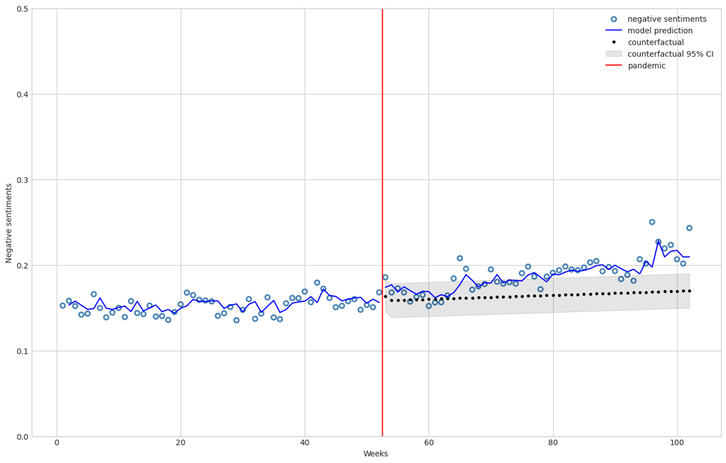

```python
start = 52
end = 102

# get the model predictions for the whole time period (start till end)
predictions = arima_results_rf.get_prediction(0, end-1)
summary = predictions.summary_frame(alpha=0.025)

# get the counterfactual ARIMA by fitting a model only for the first time period (before the pandemic)
arima_cf = ARIMA(df_rf["Y"][:start], df_rf["T"][:start], order=(0,1,2)).fit()

# model predictions means
y_pred = predictions.predicted_mean

# counterfactual mean and 95% confidence interval
y_cf = arima_cf.get_forecast(50, exog=df_rf["T"][start:]).summary_frame(alpha=0.05)

# plot section
plt.style.use('seaborn-v0_8-whitegrid')
fig, ax = plt.subplots(figsize=(16,10))

# plot weekly sentiment data
ax.scatter(df_rf["T"], df_rf["Y"], facecolors='none', edgecolors='steelblue', label="negative sentiments", linewidths=2)

# plot model mean sentiment prediction
ax.plot(df_rf["T"][1:start], y_pred[1:start], 'b-', label="model prediction")
ax.plot(df_rf["T"][start:], y_pred[start:], 'b-')

# plot counterfactual mean sentiment with 95% confidence interval
ax.plot(df_rf["T"][start:], y_cf["mean"], 'k.', label="counterfactual")
ax.fill_between(df_rf["T"][start:], y_cf['mean_ci_lower'], y_cf['mean_ci_upper'], color='k', alpha=0.1, label="counterfactual 95% CI")


# plot line marking the week of the official start of the pandemic (WHO)
ax.axvline(x = 52.5, color = 'r', label = 'pandemic')

ax.legend(loc='best')
plt.ylim([0, 0.5])
plt.xlabel("Weeks")
plt.ylabel("Negative sentiments")
```

### neg, conversational tweets - male

```python
# fit the ARIMA model automatically for conversational df
model = pm.auto_arima(df_rm["Y"], seasonal=False, trace=True)
```

```
Performing stepwise search to minimize aic
 ARIMA(2,1,2)(0,0,0)[0] intercept   : AIC=-598.298, Time=0.15 sec
 ARIMA(0,1,0)(0,0,0)[0] intercept   : AIC=-571.734, Time=0.01 sec
 ARIMA(1,1,0)(0,0,0)[0] intercept   : AIC=-574.600, Time=0.03 sec
 ARIMA(0,1,1)(0,0,0)[0] intercept   : AIC=-595.100, Time=0.07 sec
 ARIMA(0,1,0)(0,0,0)[0]             : AIC=-573.523, Time=0.02 sec
 ARIMA(1,1,2)(0,0,0)[0] intercept   : AIC=-600.903, Time=0.14 sec
 ARIMA(0,1,2)(0,0,0)[0] intercept   : AIC=inf, Time=0.12 sec
 ARIMA(1,1,1)(0,0,0)[0] intercept   : AIC=inf, Time=0.10 sec
 ARIMA(1,1,3)(0,0,0)[0] intercept   : AIC=-601.135, Time=0.31 sec
 ARIMA(0,1,3)(0,0,0)[0] intercept   : AIC=inf, Time=0.19 sec
 ARIMA(2,1,3)(0,0,0)[0] intercept   : AIC=-602.340, Time=0.05 sec
 ARIMA(3,1,3)(0,0,0)[0] intercept   : AIC=-595.418, Time=0.24 sec
 ARIMA(2,1,4)(0,0,0)[0] intercept   : AIC=-599.284, Time=0.21 sec
 ARIMA(1,1,4)(0,0,0)[0] intercept   : AIC=-596.282, Time=0.15 sec
 ARIMA(3,1,2)(0,0,0)[0] intercept   : AIC=-603.189, Time=0.15 sec
 ARIMA(3,1,1)(0,0,0)[0] intercept   : AIC=-605.025, Time=0.14 sec
 ARIMA(2,1,1)(0,0,0)[0] intercept   : AIC=-604.782, Time=0.14 sec
 ARIMA(3,1,0)(0,0,0)[0] intercept   : AIC=-584.193, Time=0.03 sec
 ARIMA(4,1,1)(0,0,0)[0] intercept   : AIC=-602.273, Time=0.19 sec
 ARIMA(2,1,0)(0,0,0)[0] intercept   : AIC=-577.308, Time=0.09 sec
 ARIMA(4,1,0)(0,0,0)[0] intercept   : AIC=-593.161, Time=0.06 sec
 ARIMA(4,1,2)(0,0,0)[0] intercept   : AIC=-599.585, Time=0.13 sec
 ARIMA(3,1,1)(0,0,0)[0]             : AIC=-598.910, Time=0.10 sec

Best model:  ARIMA(3,1,1)(0,0,0)[0] intercept
Total fit time: 2.834 seconds
```

```python
# specify ARIMA model using the proposed parameters
arima_results_rm = ARIMA(df_rm["Y"], df_rm[["T", "D"]], order=(3,1,1)).fit()
print(arima_results_rm.summary(alpha=0.025))
```

[output not shown]

```python
# Define the number of bootstrap samples
n_bootstrap_samples = 1000
coefficient_D_estimates = []

# Set the random seed for reproducibility
np.random.seed(42)

# Define the block size for block bootstrapping
block_size = 3  # how many segments of data are resampled together (I need a quite small block size to capture short-term variation (effect of the start of the pandemic))

# Perform block bootstrapping
for _ in range(n_bootstrap_samples):
    # Generate a bootstrap sample of 'Y' and 'D' using block bootstrapping
    bootstrap_indices = np.random.randint(1, len(df_rm) - block_size, len(df_rm) // block_size)
    bootstrap_indices = np.repeat(bootstrap_indices, block_size) + np.tile(np.arange(block_size), len(bootstrap_indices))
    bootstrap_sample = df_rm.iloc[bootstrap_indices]

    # Fit ARIMA model to the bootstrap sample
    bootstrap_model = ARIMA(bootstrap_sample["Y"], bootstrap_sample[["T", "D"]], order=(0, 1, 5)).fit()

    # Store the estimated coefficient for 'D'
    coefficient_D_estimates.append(bootstrap_model.params["D"])

# Calculate standard errors and confidence intervals for the coefficient of 'D'
coefficient_D_estimates = np.array(coefficient_D_estimates)
coefficient_D_std_error = coefficient_D_estimates.std()
coefficient_D_ci_lower = np.percentile(coefficient_D_estimates, 1.25)
coefficient_D_ci_upper = np.percentile(coefficient_D_estimates, 98.75)

# Print the results
print("Bootstrap Standard Error for Coefficient of 'D':", coefficient_D_std_error)
print("Bootstrap 97.5% Confidence Interval for Coefficient of 'D':")
print("Lower Bound:", coefficient_D_ci_lower)
print("Upper Bound:", coefficient_D_ci_upper)
```

```
Bootstrap Standard Error for Coefficient of 'D': 0.006550225867642331
Bootstrap 97.5% Confidence Interval for Coefficient of 'D':
Lower Bound: -0.0036817695857719913
Upper Bound: 0.02881644961281388
```

```
Bootstrap Standard Error for Coefficient of 'D': 0.006550225867642331
Bootstrap 97.5% Confidence Interval for Coefficient of 'D':
Lower Bound: -0.0036817695857719913
Upper Bound: 0.02881644961281388
```

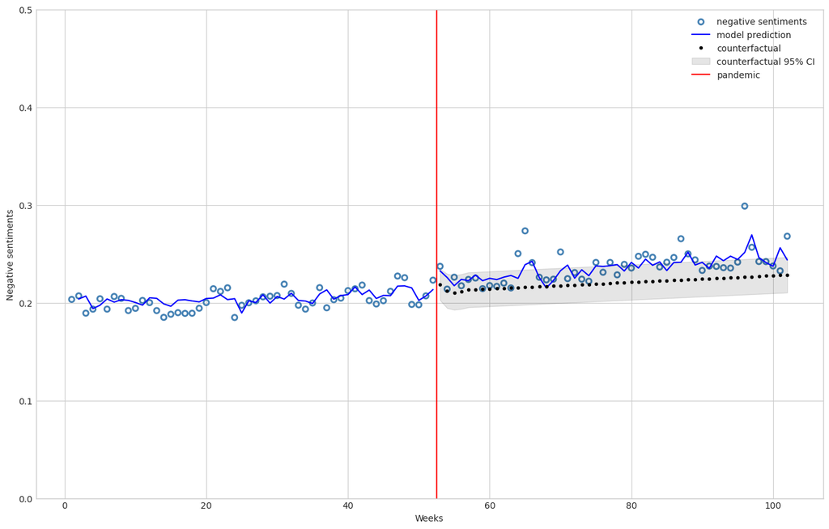

```python
start = 52
end = 102

# get the model predictions for the whole time period (start till end)
predictions = arima_results_rm.get_prediction(0, end-1)
summary = predictions.summary_frame(alpha=0.025)

# get the counterfactual ARIMA by fitting a model only for the first time period (before the pandemic)
arima_cf = ARIMA(df_rm["Y"][:start], df_rm["T"][:start], order=(0,1,5)).fit()

# model predictions means
y_pred = predictions.predicted_mean

# counterfactual mean and 95% confidence interval
y_cf = arima_cf.get_forecast(50, exog=df_rm["T"][start:]).summary_frame(alpha=0.05)

# plot section
plt.style.use('seaborn-v0_8-whitegrid')
fig, ax = plt.subplots(figsize=(16,10))

# plot weekly sentiment data
ax.scatter(df_rm["T"], df_rm["Y"], facecolors='none', edgecolors='steelblue', label="negative sentiments", linewidths=2)

# plot model mean sentiment prediction
ax.plot(df_rm["T"][1:start], y_pred[1:start], 'b-', label="model prediction")
ax.plot(df_rm["T"][start:], y_pred[start:], 'b-')

# plot counterfactual mean sentiment with 95% confidence interval
ax.plot(df_rm["T"][start:], y_cf["mean"], 'k.', label="counterfactual")
ax.fill_between(df_rm["T"][start:], y_cf['mean_ci_lower'], y_cf['mean_ci_upper'], color='k', alpha=0.1, label="counterfactual 95% CI")


# plot line marking the week of the official start of the pandemic (WHO)
ax.axvline(x = 52.5, color = 'r', label = 'pandemic')

ax.legend(loc='best')
plt.ylim([0, 0.5])
plt.xlabel("Weeks")
plt.ylabel("Negative sentiments")
```

### neg, conversational tweets - female vs. male

```python
# coefficient estimates (ARIMA) and standard errors (estimated via bootstrapping) from the two models
beta_rf = 0.0072
se_rf = 0.0089
beta_rm = 0.0093
se_rm = 0.0066

# calculate the Wald test statistic
wald_statistic = ((beta_rf - beta_rm) ** 2) / (se_rf ** 2 + se_rm ** 2)

# calculate the p-value
p_val = 1 - stats.chi2.cdf(wald_statistic, df=1) # 1 degree of freedom

# print the results
print(f"Wald Test Statistic: {wald_statistic}")
print(f"P-value: {p_val}")

# check if the coefficients are significantly different
if p_val < 0.05:
    print("Reject the null hypothesis: Coefficients are significantly different.")
else:
    print("Fail to reject the null hypothesis: Coefficients are not significantly different.")
```

```
Wald Test Statistic: 0.03592082756373705
P-value: 0.8496790847551177
Fail to reject the null hypothesis: Coefficients are not significantly different.
```

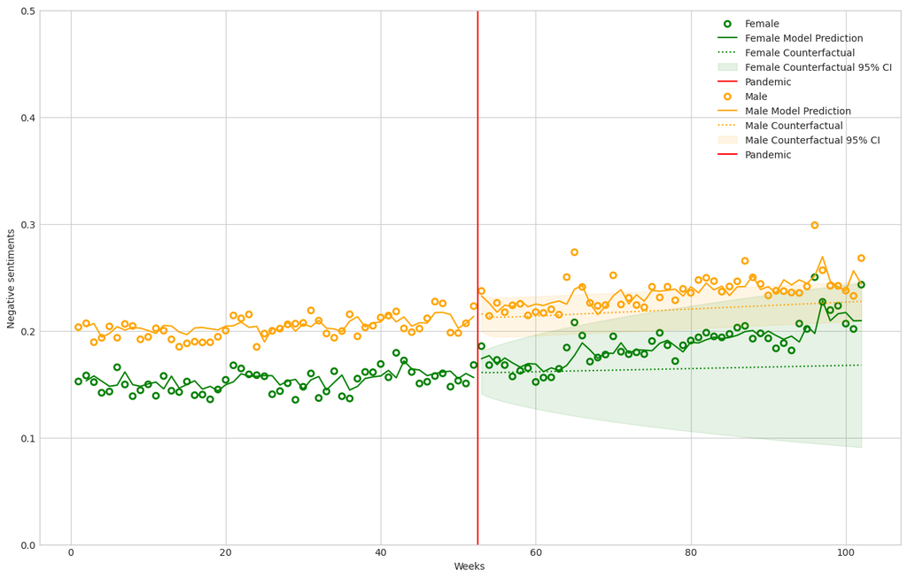

```python
# Define a function to generate the ARIMA plots
def generate_arima_plot(ax, df, arima_results, color, label):
    start = 52
    end = 102

    # get the model predictions for the whole time period (start till end)
    predictions = arima_results.get_prediction(0, end-1)

    # get the counterfactual ARIMA by fitting a model only for the first time period (before the pandemic)
    arima_cf = ARIMA(df["Y"][:start], df["T"][:start], order=(1,1,1)).fit()

    # model predictions means
    y_pred = predictions.predicted_mean

    # counterfactual mean and 95% confidence interval
    y_cf = arima_cf.get_forecast(50, exog=df["T"][start:]).summary_frame(alpha=0.05)

    # plot weekly sentiment data
    ax.scatter(df["T"], df["Y"], facecolors='none', edgecolors=color, label=label, linewidths=2)

    # plot model mean sentiment prediction
    ax.plot(df["T"][1:start], y_pred[1:start], color=color, linestyle='-', label=f"{label} Model Prediction")
    ax.plot(df["T"][start:], y_pred[start:], color=color, linestyle='-')

    # plot counterfactual mean sentiment with 95% confidence interval
    ax.plot(df["T"][start:], y_cf["mean"], color=color, linestyle='dotted', label=f"{label} Counterfactual")
    ax.fill_between(df["T"][start:], y_cf['mean_ci_lower'], y_cf['mean_ci_upper'], color=color, alpha=0.1, label=f"{label} Counterfactual 95% CI")

    # plot line marking the week of the official start of the pandemic (WHO)
    ax.axvline(x=52.5, color='r', label='Pandemic')

    ax.set_ylim([0, 0.5])
    ax.set_xlabel("Weeks")
    ax.set_ylabel("Negative sentiments")
    ax.legend(loc='best')

# Create a single plot
fig, ax = plt.subplots(figsize=(16, 10))

# Generate the first plot (female data) in green
generate_arima_plot(ax, df_rf, arima_results_rf, color='green', label='Female')

# Generate the second plot (male data) in orange
generate_arima_plot(ax, df_rm, arima_results_rm, color='orange', label='Male')

# Show the combined plot
plt.show()
```